# Study of ATC drug properties and structure from KEGG_DRUG database

- Antonio Oliver Gelabert, April 2020
- ORCID : http://orcid.org/0000-0001-8571-2733
- Linkedin : https://www.linkedin.com/in/aoliverg/?locale=en_US

ATC is european systemathic classification of accepted medicines by therapeutic usage. To see details of this classification better take a look at :

- https://en.wikipedia.org/wiki/Anatomical_Therapeutic_Chemical_Classification_System
- https://www.whocc.no/atc_ddd_index/

KEGG_DRUG database is a repository of compounds which structure is available from:

- https://www.genome.jp/kegg/drug/

The individual information about compounds can be consulted at LigandBox:

- http://www.mypresto5.com/ligandbox/

Compound structures contains information that are not always to structure. So there are some ways to structure information as

- Fingerprints (MACCS,FP2,...). http://openbabel.org/wiki/Tutorial:Fingerprints
- Molecular descriptors (USR,ElectroShape,PED,...)

For instance, PED descriptors are described in scientific literature

- https://www.nature.com/articles/srep43738

From the curated dataset combining information of this two links:

- http://www.mypresto5.com/ligandbox/cgi-bin/lbox_download.cgi?LANG=en (MOL2 FILES OF KEGG_DRUG DATABASE)
- https://www.genome.jp/kegg-bin/get_htext#A1 (KEGG ATC codes)

The information can be combined in the file 'Kegg_ATC_database_info.csv'. Lets open the file and make rapid visualization of the kind of information available:

```python
import pandas as pd
kegginfo=pd.read_csv('Kegg_ATC_database_info.csv')
kegginfo.head()
```

|  | KEGG_code | CompoundName | ATC_label_class | ATC_full_code | BigGroup_ATC_class |
| --- | --- | --- | --- | --- | --- |
| 0 | D00943 | Sodium fluoride (JAN/USP) | Caries prophylactic agents | A01AA01 | ALIMENTARY TRACT AND METABOLISM |
| 1 | D05864 | Sodium monofluorophosphate (USP) | Caries prophylactic agents | A01AA02 | ALIMENTARY TRACT AND METABOLISM |
| 2 | D05241 | Olaflur (USAN/INN) | Caries prophylactic agents | A01AA03 | ALIMENTARY TRACT AND METABOLISM |
| 3 | D05919 | Stannous fluoride (USP) | Caries prophylactic agents | A01AA04 | ALIMENTARY TRACT AND METABOLISM |
| 4 | D08736 | Sodium fluoride - phosphoric acid mixt | Caries prophylactic agents | A01AA51 | ALIMENTARY TRACT AND METABOLISM |

Now open the structure file that have been previously converted from MOL2 file to SMILES using OpenBabel (http://openbabel.org/wiki/Main_Page) and it has been converted with annotated properties. Let's see the command:

obabel -imol2 KEGG_DRUG.mol2 -osmi -O KEGG_DRUG_PROPS.smi --append 'MW' 'logP' 'MR' 'TPSA' 'HBA1' 'HBD' 'HBA2' 'InChIKey' 'formula' 'cansmiNS' 'InChI'

Adding a suitable header and converting to CSV:

```python
keggdata=pd.read_csv('ATC_KEGG_DRUG_DATABASE.csv')
keggdata.head()
```

|  | SMILES | KEGG_code | MW | logP | MR | TPSA | HBA1 | HBD | HBA2 | InChIKey | formula | cansmiNS | InChI |
| --- | --- | --- | --- | --- | --- | --- | --- | --- | --- | --- | --- | --- | --- |
| 0 | P(=O)(O)(O)F | D05864 | 99.9862 | 0.0486 | 13.1521 | 67.34 | 3 | 2 | 3 | DWYMPOCYEZONEA-UHFFFAOYSA-N | FH2O3P | OP(=O)(F)O | InChI=1S/FH2O3P/c1-5(2,3)4/h(H2,2,3,4) |
| 1 | [N@@H+](CCCCCCCCCCCCCCCCCC)(CCC[NH+](CCO)CCO)CCO | D05241 | 460.7770 | 2.3847 | 143.6960 | 69.57 | 63 | 5 | 3 | KRZCNRGNPAESDC-UHFFFAOYSA-P | C27H60N2O3++ | CCCCCCCCCCCCCCCCCC[NH+](CCC[NH+](CCO)CCO)CCO | InChI=1S/C27H58N2O3/c1-2-3-4-5-6-7-8-9-10-11-1... |
| 2 | OO | D00008 | 34.0147 | 0.0174 | 5.2576 | 40.46 | 4 | 2 | 2 | MHAJPDPJQMAIIY-UHFFFAOYSA-N | H2O2 | OO | InChI=1S/H2O2/c1-2/h1-2H |
| 3 | c1(NC(=[NH2])NC(=[NH2])NCCCCCCNC(=[NH2])NC(=[N... | D07668 | 509.4780 | 7.1406 | 147.2780 | 176.26 | 44 | 10 | 6 | QZENBIWUJQPOMN-UHFFFAOYSA-N | C22H34Cl2N10 | [NH2]=C(NC(=[NH2])Nc1ccc(cc1)Cl)NCCCCCCNC(=[NH... | InChI=1S/C22H34Cl2N10/c23-15-5-9-17(10-6-15)31... |
| 4 | c1(NC(=[NH2])NC(=[NH2])NCCCCCCNC(=[NH2])NC(=[N... | D00858 | 509.4780 | 7.1406 | 147.2780 | 176.26 | 44 | 10 | 6 | QZENBIWUJQPOMN-UHFFFAOYSA-N | C22H34Cl2N10 | [NH2]=C(NC(=[NH2])Nc1ccc(cc1)Cl)NCCCCCCNC(=[NH... | InChI=1S/C22H34Cl2N10/c23-15-5-9-17(10-6-15)31... |

Now lets combine both files to one using merge and KEGG codes:

```python
keggcompl=pd.merge(kegginfo,keggdata,on='KEGG_code')
keggcompl
```

|  | KEGG_code | CompoundName | ATC_label_class | ATC_full_code | BigGroup_ATC_class | SMILES | MW | logP | MR | TPSA | HBA1 | HBD | HBA2 | InChIKey | formula | cansmiNS | InChI |
| --- | --- | --- | --- | --- | --- | --- | --- | --- | --- | --- | --- | --- | --- | --- | --- | --- | --- |
| 0 | D05864 | Sodium monofluorophosphate (USP) | Caries prophylactic agents | A01AA02 | ALIMENTARY TRACT AND METABOLISM | P(=O)(O)(O)F | 99.9862 | 0.0486 | 13.1521 | 67.34 | 3 | 2 | 3 | DWYMPOCYEZONEA-UHFFFAOYSA-N | FH2O3P | OP(=O)(F)O | InChI=1S/FH2O3P/c1-5(2,3)4/h(H2,2,3,4) |
| 1 | D05864 | Sodium monofluorophosphate (USP) | Caries prophylactic agents | A01AA02 | ALIMENTARY TRACT AND METABOLISM | P(=O)(O)(O)F | 99.9862 | 0.0486 | 13.1521 | 67.34 | 3 | 2 | 3 | DWYMPOCYEZONEA-UHFFFAOYSA-N | FH2O3P | OP(=O)(F)O | InChI=1S/FH2O3P/c1-5(2,3)4/h(H2,2,3,4) |
| 2 | D05864 | Sodium monofluorophosphate (USP) | Fluoride | A12CD02 | ALIMENTARY TRACT AND METABOLISM | P(=O)(O)(O)F | 99.9862 | 0.0486 | 13.1521 | 67.34 | 3 | 2 | 3 | DWYMPOCYEZONEA-UHFFFAOYSA-N | FH2O3P | OP(=O)(F)O | InChI=1S/FH2O3P/c1-5(2,3)4/h(H2,2,3,4) |
| 3 | D05864 | Sodium monofluorophosphate (USP) | Fluoride | A12CD02 | ALIMENTARY TRACT AND METABOLISM | P(=O)(O)(O)F | 99.9862 | 0.0486 | 13.1521 | 67.34 | 3 | 2 | 3 | DWYMPOCYEZONEA-UHFFFAOYSA-N | FH2O3P | OP(=O)(F)O | InChI=1S/FH2O3P/c1-5(2,3)4/h(H2,2,3,4) |
| 4 | D05241 | Olaflur (USAN/INN) | Caries prophylactic agents | A01AA03 | ALIMENTARY TRACT AND METABOLISM | [N@@H+](CCCCCCCCCCCCCCCCCC)(CCC[NH+](CCO)CCO)CCO | 460.7770 | 2.3847 | 143.6960 | 69.57 | 63 | 5 | 3 | KRZCNRGNPAESDC-UHFFFAOYSA-P | C27H60N2O3++ | CCCCCCCCCCCCCCCCCC[NH+](CCC[NH+](CCO)CCO)CCO | InChI=1S/C27H58N2O3/c1-2-3-4-5-6-7-8-9-10-11-1... |
| 5 | D00008 | Hydrogen peroxide (USP) | Antiinfectives and antiseptics for local oral... | A01AB02 | ALIMENTARY TRACT AND METABOLISM | OO | 34.0147 | 0.0174 | 5.2576 | 40.46 | 4 | 2 | 2 | MHAJPDPJQMAIIY-UHFFFAOYSA-N | H2O2 | OO | InChI=1S/H2O2/c1-2/h1-2H |
| 6 | D00008 | Hydrogen peroxide (USP) | Antiinfectives and antiseptics for local oral... | A01AB02 | ALIMENTARY TRACT AND METABOLISM | OO | 34.0147 | 0.0174 | 5.2576 | 40.46 | 4 | 2 | 2 | MHAJPDPJQMAIIY-UHFFFAOYSA-N | H2O2 | OO | InChI=1S/H2O2/c1-2/h1-2H |
| 7 | D00008 | Hydrogen peroxide (USP) | Antiinfectives and antiseptics for local oral... | A01AB02 | ALIMENTARY TRACT AND METABOLISM | OO | 34.0147 | 0.0174 | 5.2576 | 40.46 | 4 | 2 | 2 | MHAJPDPJQMAIIY-UHFFFAOYSA-N | H2O2 | OO | InChI=1S/H2O2/c1-2/h1-2H |
| 8 | D00008 | Hydrogen peroxide (USP) | Other antiseptics and disinfectants | D08AX01 | DERMATOLOGICALS | OO | 34.0147 | 0.0174 | 5.2576 | 40.46 | 4 | 2 | 2 | MHAJPDPJQMAIIY-UHFFFAOYSA-N | H2O2 | OO | InChI=1S/H2O2/c1-2/h1-2H |
| 9 | D00008 | Hydrogen peroxide (USP) | Other antiseptics and disinfectants | D08AX01 | DERMATOLOGICALS | OO | 34.0147 | 0.0174 | 5.2576 | 40.46 | 4 | 2 | 2 | MHAJPDPJQMAIIY-UHFFFAOYSA-N | H2O2 | OO | InChI=1S/H2O2/c1-2/h1-2H |
| 10 | D00008 | Hydrogen peroxide (USP) | Other antiseptics and disinfectants | D08AX01 | DERMATOLOGICALS | OO | 34.0147 | 0.0174 | 5.2576 | 40.46 | 4 | 2 | 2 | MHAJPDPJQMAIIY-UHFFFAOYSA-N | H2O2 | OO | InChI=1S/H2O2/c1-2/h1-2H |
| 11 | D00008 | Hydrogen peroxide (USP) | Antiinfectives | S02AA06 | SENSORY ORGANS | OO | 34.0147 | 0.0174 | 5.2576 | 40.46 | 4 | 2 | 2 | MHAJPDPJQMAIIY-UHFFFAOYSA-N | H2O2 | OO | InChI=1S/H2O2/c1-2/h1-2H |
| 12 | D00008 | Hydrogen peroxide (USP) | Antiinfectives | S02AA06 | SENSORY ORGANS | OO | 34.0147 | 0.0174 | 5.2576 | 40.46 | 4 | 2 | 2 | MHAJPDPJQMAIIY-UHFFFAOYSA-N | H2O2 | OO | InChI=1S/H2O2/c1-2/h1-2H |
| 13 | D00008 | Hydrogen peroxide (USP) | Antiinfectives | S02AA06 | SENSORY ORGANS | OO | 34.0147 | 0.0174 | 5.2576 | 40.46 | 4 | 2 | 2 | MHAJPDPJQMAIIY-UHFFFAOYSA-N | H2O2 | OO | InChI=1S/H2O2/c1-2/h1-2H |
| 14 | D07668 | Chlorhexidine (INN) | Antiinfectives and antiseptics for local oral... | A01AB03 | ALIMENTARY TRACT AND METABOLISM | c1(NC(=[NH2])NC(=[NH2])NCCCCCCNC(=[NH2])NC(=[N... | 509.4780 | 7.1406 | 147.2780 | 176.26 | 44 | 10 | 6 | QZENBIWUJQPOMN-UHFFFAOYSA-N | C22H34Cl2N10 | [NH2]=C(NC(=[NH2])Nc1ccc(cc1)Cl)NCCCCCCNC(=[NH... | InChI=1S/C22H34Cl2N10/c23-15-5-9-17(10-6-15)31... |
| 15 | D07668 | Chlorhexidine (INN) | Antiinfectives and antiseptics for local oral... | A01AB03 | ALIMENTARY TRACT AND METABOLISM | c1(NC(=[NH2])NC(=[NH2])NCCCCCCNC(=[NH2])NC(=[N... | 509.4780 | 7.1406 | 147.2780 | 176.26 | 44 | 10 | 6 | QZENBIWUJQPOMN-UHFFFAOYSA-N | C22H34Cl2N10 | [NH2]=C(NC(=[NH2])Nc1ccc(cc1)Cl)NCCCCCCNC(=[NH... | InChI=1S/C22H34Cl2N10/c23-15-5-9-17(10-6-15)31... |
| 16 | D07668 | Chlorhexidine (INN) | Antiinfectives and antiseptics for local oral... | A01AB03 | ALIMENTARY TRACT AND METABOLISM | c1(NC(=[NH2])NC(=[NH2])NCCCCCCNC(=[NH2])NC(=[N... | 509.4780 | 7.1406 | 147.2780 | 176.26 | 44 | 10 | 6 | QZENBIWUJQPOMN-UHFFFAOYSA-N | C22H34Cl2N10 | [NH2]=C(NC(=[NH2])Nc1ccc(cc1)Cl)NCCCCCCNC(=[NH... | InChI=1S/C22H34Cl2N10/c23-15-5-9-17(10-6-15)31... |
| 17 | D07668 | Chlorhexidine (INN) | Antiinfectives and antiseptics for local oral... | A01AB03 | ALIMENTARY TRACT AND METABOLISM | c1(NC(=[NH2])NC(=[NH2])NCCCCCCNC(=[NH2])NC(=[N... | 509.4780 | 7.1406 | 147.2780 | 176.26 | 44 | 10 | 6 | QZENBIWUJQPOMN-UHFFFAOYSA-N | C22H34Cl2N10 | [NH2]=C(NC(=[NH2])Nc1ccc(cc1)Cl)NCCCCCCNC(=[NH... | InChI=1S/C22H34Cl2N10/c23-15-5-9-17(10-6-15)31... |
| 18 | D07668 | Chlorhexidine (INN) | Antiinfectives and antiseptics for local oral... | A01AB03 | ALIMENTARY TRACT AND METABOLISM | c1(NC(=[NH2])NC(=[NH2])NCCCCCCNC(=[NH2])NC(=[N... | 509.4780 | 7.1406 | 147.2780 | 176.26 | 44 | 10 | 6 | QZENBIWUJQPOMN-UHFFFAOYSA-N | C22H34Cl2N10 | [NH2]=C(NC(=[NH2])Nc1ccc(cc1)Cl)NCCCCCCNC(=[NH... | InChI=1S/C22H34Cl2N10/c23-15-5-9-17(10-6-15)31... |
| 19 | D07668 | Chlorhexidine (INN) | Antiinfectives and antiseptics for local oral... | A01AB03 | ALIMENTARY TRACT AND METABOLISM | c1(NC(=[NH2])NC(=[NH2])NCCCCCCNC(=[NH2])NC(=[N... | 509.4780 | 7.1406 | 147.2780 | 176.26 | 44 | 10 | 6 | QZENBIWUJQPOMN-UHFFFAOYSA-N | C22H34Cl2N10 | [NH2]=C(NC(=[NH2])Nc1ccc(cc1)Cl)NCCCCCCNC(=[NH... | InChI=1S/C22H34Cl2N10/c23-15-5-9-17(10-6-15)31... |
| 20 | D07668 | Chlorhexidine (INN) | Antiinfectives and antiseptics for local oral... | A01AB03 | ALIMENTARY TRACT AND METABOLISM | c1(NC(=[NH2])NC(=[NH2])NCCCCCCNC(=[NH2])NC(=[N... | 509.4780 | 7.1406 | 147.2780 | 176.26 | 44 | 10 | 6 | QZENBIWUJQPOMN-UHFFFAOYSA-N | C22H34Cl2N10 | [NH2]=C(NC(=[NH2])Nc1ccc(cc1)Cl)NCCCCCCNC(=[NH... | InChI=1S/C22H34Cl2N10/c23-15-5-9-17(10-6-15)31... |
| 21 | D07668 | Chlorhexidine (INN) | Antiinfectives and antiseptics for local oral... | A01AB03 | ALIMENTARY TRACT AND METABOLISM | c1(NC(=[NH2])NC(=[NH2])NCCCCCCNC(=[NH2])NC(=[N... | 509.4780 | 7.1406 | 147.2780 | 176.26 | 44 | 10 | 6 | QZENBIWUJQPOMN-UHFFFAOYSA-N | C22H34Cl2N10 | [NH2]=C(NC(=[NH2])Nc1ccc(cc1)Cl)NCCCCCCNC(=[NH... | InChI=1S/C22H34Cl2N10/c23-15-5-9-17(10-6-15)31... |
| 22 | D07668 | Chlorhexidine (INN) | Antiinfectives | B05CA02 | BLOOD AND BLOOD FORMING ORGANS | c1(NC(=[NH2])NC(=[NH2])NCCCCCCNC(=[NH2])NC(=[N... | 509.4780 | 7.1406 | 147.2780 | 176.26 | 44 | 10 | 6 | QZENBIWUJQPOMN-UHFFFAOYSA-N | C22H34Cl2N10 | [NH2]=C(NC(=[NH2])Nc1ccc(cc1)Cl)NCCCCCCNC(=[NH... | InChI=1S/C22H34Cl2N10/c23-15-5-9-17(10-6-15)31... |
| 23 | D07668 | Chlorhexidine (INN) | Antiinfectives | B05CA02 | BLOOD AND BLOOD FORMING ORGANS | c1(NC(=[NH2])NC(=[NH2])NCCCCCCNC(=[NH2])NC(=[N... | 509.4780 | 7.1406 | 147.2780 | 176.26 | 44 | 10 | 6 | QZENBIWUJQPOMN-UHFFFAOYSA-N | C22H34Cl2N10 | [NH2]=C(NC(=[NH2])Nc1ccc(cc1)Cl)NCCCCCCNC(=[NH... | InChI=1S/C22H34Cl2N10/c23-15-5-9-17(10-6-15)31... |
| 24 | D07668 | Chlorhexidine (INN) | Antiinfectives | B05CA02 | BLOOD AND BLOOD FORMING ORGANS | c1(NC(=[NH2])NC(=[NH2])NCCCCCCNC(=[NH2])NC(=[N... | 509.4780 | 7.1406 | 147.2780 | 176.26 | 44 | 10 | 6 | QZENBIWUJQPOMN-UHFFFAOYSA-N | C22H34Cl2N10 | [NH2]=C(NC(=[NH2])Nc1ccc(cc1)Cl)NCCCCCCNC(=[NH... | InChI=1S/C22H34Cl2N10/c23-15-5-9-17(10-6-15)31... |
| 25 | D07668 | Chlorhexidine (INN) | Antiinfectives | B05CA02 | BLOOD AND BLOOD FORMING ORGANS | c1(NC(=[NH2])NC(=[NH2])NCCCCCCNC(=[NH2])NC(=[N... | 509.4780 | 7.1406 | 147.2780 | 176.26 | 44 | 10 | 6 | QZENBIWUJQPOMN-UHFFFAOYSA-N | C22H34Cl2N10 | [NH2]=C(NC(=[NH2])Nc1ccc(cc1)Cl)NCCCCCCNC(=[NH... | InChI=1S/C22H34Cl2N10/c23-15-5-9-17(10-6-15)31... |
| 26 | D07668 | Chlorhexidine (INN) | Antiinfectives | B05CA02 | BLOOD AND BLOOD FORMING ORGANS | c1(NC(=[NH2])NC(=[NH2])NCCCCCCNC(=[NH2])NC(=[N... | 509.4780 | 7.1406 | 147.2780 | 176.26 | 44 | 10 | 6 | QZENBIWUJQPOMN-UHFFFAOYSA-N | C22H34Cl2N10 | [NH2]=C(NC(=[NH2])Nc1ccc(cc1)Cl)NCCCCCCNC(=[NH... | InChI=1S/C22H34Cl2N10/c23-15-5-9-17(10-6-15)31... |
| 27 | D07668 | Chlorhexidine (INN) | Antiinfectives | B05CA02 | BLOOD AND BLOOD FORMING ORGANS | c1(NC(=[NH2])NC(=[NH2])NCCCCCCNC(=[NH2])NC(=[N... | 509.4780 | 7.1406 | 147.2780 | 176.26 | 44 | 10 | 6 | QZENBIWUJQPOMN-UHFFFAOYSA-N | C22H34Cl2N10 | [NH2]=C(NC(=[NH2])Nc1ccc(cc1)Cl)NCCCCCCNC(=[NH... | InChI=1S/C22H34Cl2N10/c23-15-5-9-17(10-6-15)31... |
| 28 | D07668 | Chlorhexidine (INN) | Antiinfectives | B05CA02 | BLOOD AND BLOOD FORMING ORGANS | c1(NC(=[NH2])NC(=[NH2])NCCCCCCNC(=[NH2])NC(=[N... | 509.4780 | 7.1406 | 147.2780 | 176.26 | 44 | 10 | 6 | QZENBIWUJQPOMN-UHFFFAOYSA-N | C22H34Cl2N10 | [NH2]=C(NC(=[NH2])Nc1ccc(cc1)Cl)NCCCCCCNC(=[NH... | InChI=1S/C22H34Cl2N10/c23-15-5-9-17(10-6-15)31... |
| 29 | D07668 | Chlorhexidine (INN) | Antiinfectives | B05CA02 | BLOOD AND BLOOD FORMING ORGANS | c1(NC(=[NH2])NC(=[NH2])NCCCCCCNC(=[NH2])NC(=[N... | 509.4780 | 7.1406 | 147.2780 | 176.26 | 44 | 10 | 6 | QZENBIWUJQPOMN-UHFFFAOYSA-N | C22H34Cl2N10 | [NH2]=C(NC(=[NH2])Nc1ccc(cc1)Cl)NCCCCCCNC(=[NH... | InChI=1S/C22H34Cl2N10/c23-15-5-9-17(10-6-15)31... |
| ... | ... | ... | ... | ... | ... | ... | ... | ... | ... | ... | ... | ... | ... | ... | ... | ... | ... |
| 14209 | D09617 | Florbetapir F-18 (USAN) | Other central nervous system diagnostic radio... | V09AX05 | VARIOUS | c1(ccc(cc1)/C=C/c1cnc(cc1)OCCOCCOCCF)NC | 360.4230 | 3.7482 | 101.6610 | 52.61 | 30 | 1 | 5 | YNDIAUKFXKEXSV-NSCUHMNNSA-N | C20H25FN2O3 | FCCOCCOCCOc1ccc(cn1)C=Cc1ccc(cc1)NC | InChI=1S/C20H25FN2O3/c1-22-19-7-4-17(5-8-19)2-... |
| 14210 | D10002 | Florbetaben (18F) (JAN/INN) | Other central nervous system diagnostic radio... | V09AX06 | VARIOUS | c1(ccc(cc1)/C=C/c1ccc(cc1)OCCOCCOCCF)NC | 359.4340 | 4.3532 | 103.8660 | 39.72 | 30 | 1 | 4 | NCWZOASIUQVOFA-NSCUHMNNSA-N | C21H26FNO3 | FCCOCCOCCOc1ccc(cc1)C=Cc1ccc(cc1)NC | InChI=1S/C21H26FNO3/c1-23-20-8-4-18(5-9-20)2-3... |
| 14211 | D02029 | Technetium Tc 99m medronate (USP) | Technetium (99mTc) compounds | V09BA02 | VARIOUS | P(=O)(CP(=O)(O)O)(O)O | 176.0020 | -0.7007 | 28.8952 | 134.68 | 8 | 4 | 6 | MBKDYNNUVRNNRF-UHFFFAOYSA-N | CH6O6P2 | OP(=O)(CP(=O)(O)O)O | InChI=1S/CH6O6P2/c2-8(3,4)1-9(5,6)7/h1H2,(H2,2... |
| 14212 | D02025 | Technetium Tc 99m succimer (USP) | Technetium (99mTc) compounds | V09CA02 | VARIOUS | OC(=O)[C@H]([C@@H](C(=O)O)S)S | 182.2180 | -0.2476 | 40.7436 | 152.20 | 10 | 4 | 6 | ACTRVOBWPAIOHC-LWMBPPNESA-N | C4H6O4S2 | SC(C(C(=O)O)S)C(=O)O | InChI=1S/C4H6O4S2/c5-3(6)1(9)2(10)4(7)8/h1-2,9... |
| 14213 | D06039 | Technetium Tc 99m mertiatide (USP) | Technetium (99mTc) compounds | V09CA03 | VARIOUS | N(C(=O)CNC(=O)CNC(=O)CS)CC(=O)O | 263.2710 | -1.4779 | 59.2759 | 163.40 | 17 | 5 | 9 | RXACEEPNTRHYBQ-UHFFFAOYSA-N | C8H13N3O5S | SCC(=O)NCC(=O)NCC(=O)NCC(=O)O | InChI=1S/C8H13N3O5S/c12-5(2-10-7(14)4-17)9-1-6... |
| 14214 | D04568 | Iodohippurate sodium I 123 (USP) | Other renal system diagnostic radiopharmaceut... | V09CX01 | VARIOUS | c1ccc(c(c1)I)C(=O)NCC(=O)O | 305.0690 | 1.4965 | 58.7340 | 66.40 | 11 | 2 | 4 | CORFWQGVBFFZHF-UHFFFAOYSA-N | C9H8INO3 | OC(=O)CNC(=O)c1ccccc1I | InChI=1S/C9H8INO3/c10-7-4-2-1-3-6(7)9(14)11-5-... |
| 14215 | D04570 | Iodohippurate sodium I 131 (USAN) | Other renal system diagnostic radiopharmaceut... | V09CX02 | VARIOUS | c1ccc(c(c1)I)C(=O)NCC(=O)O | 305.0690 | 1.4965 | 58.7340 | 66.40 | 11 | 2 | 4 | CORFWQGVBFFZHF-UHFFFAOYSA-N | C9H8INO3 | OC(=O)CNC(=O)c1ccccc1I | InChI=1S/C9H8INO3/c10-7-4-2-1-3-6(7)9(14)11-5-... |
| 14216 | D06891 | Chromium Cr 51 Edetate (USP) | Other renal system diagnostic radiopharmaceut... | V09CX04 | VARIOUS | [NH+](CC[NH+](CC(=O)O)CC(=O)O)(CC(=O)O)CC(=O)O | 294.2590 | -4.9054 | 65.5786 | 158.08 | 22 | 6 | 8 | KCXVZYZYPLLWCC-UHFFFAOYSA-P | C10H18N2O8++ | OC(=O)C[NH+](CC(=O)O)CC[NH+](CC(=O)O)CC(=O)O | InChI=1S/C10H16N2O8/c13-7(14)3-11(4-8(15)16)1-... |
| 14217 | D06049 | Technetium Tc 99m teboroxime (USAN) | Technetium (99mTc) compounds | V09GA03 | VARIOUS | N(=C\1/C(=N\O)/CCCC1)\O | 142.1560 | 1.2208 | 37.6710 | 65.18 | 12 | 2 | 4 | CUNNCKOPAWXYDX-KQQUZDAGSA-N | C6H10N2O2 | ON=C1CCCCC1=NO | InChI=1S/C6H10N2O2/c9-7-5-3-1-2-4-6(5)8-10/h9-... |
| 14218 | D06042 | Technetium Tc 99m pentetate (USP) | Technetium (99mTc) compounds | V09GA04 | VARIOUS | C(=O)(C[NH+](CC[NH+](CC(=O)O)CC[NH+](CC(=O)O)C... | 396.3700 | -6.9359 | 90.7321 | 199.82 | 31 | 8 | 10 | QPCDCPDFJACHGM-UHFFFAOYSA-Q | C14H26N3O10+++ | OC(=O)C[NH+](CC[NH+](CC(=O)O)CC(=O)O)CC[NH+](C... | InChI=1S/C14H23N3O10/c18-10(19)5-15(1-3-16(6-1... |
| 14219 | D06027 | Technetium Tc 99m apcitide (USP) | Technetium (99mTc) compounds | V09GA07 | VARIOUS | C1C(=O)N[C@@H](C(=O)N[C@@H](C(=O)NCC(=O)N[C@@H... | 1393.5900 | -4.0658 | 354.3630 | 704.76 | 113 | 20 | 40 | MEMKXPGBFFKUER-HVVKFRKYSA-O | C51H78N17O19S5+ | [NH3+]CCCSCC1NC(=O)C(NC(=O)CSCC(NC(=O)C(NC(=O)... | InChI=1S/C51H77N17O19S5/c1-26(69)60-24-91-21-3... |
| 14220 | D01936 | Gallium citrate Ga 67 (USP) | Other diagnostic radiopharmaceuticals for inf... | V09HX01 | VARIOUS | C(CC(=O)O)(CC(=O)O)(C(=O)O)O | 192.1240 | -1.2485 | 37.4712 | 132.13 | 12 | 4 | 7 | KRKNYBCHXYNGOX-UHFFFAOYSA-N | C6H8O7 | OC(=O)C(CC(=O)O)(CC(=O)O)O | InChI=1S/C6H8O7/c7-3(8)1-6(13,5(11)12)2-4(9)10... |
| 14221 | D02108 | Indium In 111 pentetreotide (USP) | Indium (111In) compounds | V09IB01 | VARIOUS | O=C(C[N@H+](CC[NH+](CC(=O)O)CC(=O)O)CC[N@H+](C... | 1398.6000 | -5.5549 | 377.7880 | 550.04 | 116 | 20 | 29 | CNLWNYCFDMAZCB-HCHSMLBTSA-R | C63H91N13O19S2++++ | [NH3+]CCCCC1NC(=O)C(NC(=O)C(Cc2ccccc2)NC(=O)C(... | InChI=1S/C63H87N13O19S2/c1-37(78)48(34-77)70-6... |
| 14222 | D01729 | 3-Iodobenzylguanidine (123I) (JAN) | Other diagnostic radiopharmaceuticals for tum... | V09IX01 | VARIOUS | c1ccc(cc1CNC(=[NH2])N)I | 276.0980 | 2.6794 | 58.9945 | 64.07 | 14 | 3 | 2 | XASKLFCJRRFMGR-UHFFFAOYSA-N | C8H11IN3 | NC(=[NH2])NCc1cccc(c1)I | InChI=1S/C8H11IN3/c9-7-3-1-2-6(4-7)5-12-8(10)1... |
| 14223 | D04559 | Iobenguane sulfate I 123 (USAN) | Other diagnostic radiopharmaceuticals for tum... | V09IX01 | VARIOUS | c1ccc(cc1CNC(=[NH2])N)I | 276.0980 | 2.6794 | 58.9945 | 64.07 | 14 | 3 | 2 | XASKLFCJRRFMGR-UHFFFAOYSA-N | C8H11IN3 | NC(=[NH2])NCc1cccc(c1)I | InChI=1S/C8H11IN3/c9-7-3-1-2-6(4-7)5-12-8(10)1... |
| 14224 | D03308 | Iobenguane I 131 (USP) | Other diagnostic radiopharmaceuticals for tum... | V09IX02 | VARIOUS | c1c(cc(cc1)I)CNC(=[NH2])N | 276.0980 | 2.6794 | 58.9945 | 64.07 | 14 | 3 | 2 | XASKLFCJRRFMGR-UHFFFAOYSA-N | C8H11IN3 | NC(=[NH2])NCc1cccc(c1)I | InChI=1S/C8H11IN3/c9-7-3-1-2-6(4-7)5-12-8(10)1... |
| 14225 | D03308 | Iobenguane I 131 (USP) | Other diagnostic radiopharmaceuticals for tum... | V09IX02 | VARIOUS | c1c(cc(cc1)I)CNC(=[NH2])N | 276.0980 | 2.6794 | 58.9945 | 64.07 | 14 | 3 | 2 | XASKLFCJRRFMGR-UHFFFAOYSA-N | C8H11IN3 | NC(=[NH2])NCc1cccc(c1)I | InChI=1S/C8H11IN3/c9-7-3-1-2-6(4-7)5-12-8(10)1... |
| 14226 | D03308 | Iobenguane I 131 (USP) | Iodine (131I) compounds | V10XA02 | VARIOUS | c1c(cc(cc1)I)CNC(=[NH2])N | 276.0980 | 2.6794 | 58.9945 | 64.07 | 14 | 3 | 2 | XASKLFCJRRFMGR-UHFFFAOYSA-N | C8H11IN3 | NC(=[NH2])NCc1cccc(c1)I | InChI=1S/C8H11IN3/c9-7-3-1-2-6(4-7)5-12-8(10)1... |
| 14227 | D03308 | Iobenguane I 131 (USP) | Iodine (131I) compounds | V10XA02 | VARIOUS | c1c(cc(cc1)I)CNC(=[NH2])N | 276.0980 | 2.6794 | 58.9945 | 64.07 | 14 | 3 | 2 | XASKLFCJRRFMGR-UHFFFAOYSA-N | C8H11IN3 | NC(=[NH2])NCc1cccc(c1)I | InChI=1S/C8H11IN3/c9-7-3-1-2-6(4-7)5-12-8(10)1... |
| 14228 | D04560 | Iobenguane sulfate I 131 (USAN) | Other diagnostic radiopharmaceuticals for tum... | V09IX02 | VARIOUS | c1ccc(cc1CNC(=[NH2])N)I | 276.0980 | 2.6794 | 58.9945 | 64.07 | 14 | 3 | 2 | XASKLFCJRRFMGR-UHFFFAOYSA-N | C8H11IN3 | NC(=[NH2])NCc1cccc(c1)I | InChI=1S/C8H11IN3/c9-7-3-1-2-6(4-7)5-12-8(10)1... |
| 14229 | D04560 | Iobenguane sulfate I 131 (USAN) | Other diagnostic radiopharmaceuticals for tum... | V09IX02 | VARIOUS | c1ccc(cc1CNC(=[NH2])N)I | 276.0980 | 2.6794 | 58.9945 | 64.07 | 14 | 3 | 2 | XASKLFCJRRFMGR-UHFFFAOYSA-N | C8H11IN3 | NC(=[NH2])NCc1cccc(c1)I | InChI=1S/C8H11IN3/c9-7-3-1-2-6(4-7)5-12-8(10)1... |
| 14230 | D04560 | Iobenguane sulfate I 131 (USAN) | Iodine (131I) compounds | V10XA02 | VARIOUS | c1ccc(cc1CNC(=[NH2])N)I | 276.0980 | 2.6794 | 58.9945 | 64.07 | 14 | 3 | 2 | XASKLFCJRRFMGR-UHFFFAOYSA-N | C8H11IN3 | NC(=[NH2])NCc1cccc(c1)I | InChI=1S/C8H11IN3/c9-7-3-1-2-6(4-7)5-12-8(10)1... |
| 14231 | D04560 | Iobenguane sulfate I 131 (USAN) | Iodine (131I) compounds | V10XA02 | VARIOUS | c1ccc(cc1CNC(=[NH2])N)I | 276.0980 | 2.6794 | 58.9945 | 64.07 | 14 | 3 | 2 | XASKLFCJRRFMGR-UHFFFAOYSA-N | C8H11IN3 | NC(=[NH2])NCc1cccc(c1)I | InChI=1S/C8H11IN3/c9-7-3-1-2-6(4-7)5-12-8(10)1... |
| 14232 | D01843 | Fludeoxyglucose F 18 (USP) | Other diagnostic radiopharmaceuticals for tum... | V09IX04 | VARIOUS | [C@H]1([C@H]([C@@H]([C@H](O[C@@H]1O)CO)O)O)F | 182.1470 | -2.2442 | 34.6252 | 90.15 | 16 | 4 | 5 | ZCXUVYAZINUVJD-UKFBFLRUSA-N | C6H11FO5 | OCC1OC(O)C(C(C1O)O)F | InChI=1S/C6H11FO5/c7-3-5(10)4(9)2(1-8)12-6(3)1... |
| 14233 | D04220 | Fluorodopa F 18 (USP) | Other diagnostic radiopharmaceuticals for tum... | V09IX05 | VARIOUS | c1c(c(cc(c1F)C[C@@H](C(=O)O)[NH3+])O)O | 216.1860 | -0.5255 | 50.7629 | 105.40 | 14 | 4 | 4 | PAXWQORCRCBOCU-LURJTMIESA-O | C9H11FNO4+ | OC(=O)C(Cc1cc(O)c(cc1F)O)[NH3+] | InChI=1S/C9H10FNO4/c10-5-3-8(13)7(12)2-4(5)1-6... |
| 14234 | D04567 | Iodocholesterol I 131 (USAN) | Iodine (131I) compounds | V09XA02 | VARIOUS | [C@H]12[C@H]3[C@@H]([C@@]4(C(=CC3)C[C@H](CC4)O... | 512.5500 | 7.8038 | 136.5780 | 20.23 | 46 | 1 | 1 | FIOAEFCJGZJUPW-FTLVODPJSA-N | C27H45IO | ICC12CCC(CC1=CCC1C2CCC2(C1CCC2C(CCCC(C)C)C)C)O | InChI=1S/C27H45IO/c1-18(2)6-5-7-19(3)23-10-11-... |
| 14235 | D02464 | Ferric citrate (59 Fe) | Various diagnostic radiopharmaceuticals | V09XX04 | VARIOUS | C(=O)(O)C(CC(=O)O)(CC(=O)O)O | 192.1240 | -1.2485 | 37.4712 | 132.13 | 12 | 4 | 7 | KRKNYBCHXYNGOX-UHFFFAOYSA-N | C6H8O7 | OC(=O)C(CC(=O)O)(CC(=O)O)O | InChI=1S/C6H8O7/c7-3(8)1-6(13,5(11)12)2-4(9)10... |
| 14236 | D08504 | Samarium (153Sm) lexidronam (INN) | Various pain palliation radiopharmaceuticals | V10BX02 | VARIOUS | C(C[NH+](CP(=O)(O)O)CP(=O)(O)O)[NH+](CP(=O)(O)... | 438.1400 | -4.7030 | 83.2118 | 278.24 | 26 | 10 | 12 | NFDRPXJGHKJRLJ-UHFFFAOYSA-P | C6H22N2O12P4++ | OP(=O)(C[NH+](CP(=O)(O)O)CC[NH+](CP(=O)(O)O)CP... | InChI=1S/C6H20N2O12P4/c9-21(10,11)3-7(4-22(12,... |
| 14237 | D05795 | Samarium Sm 153 lexidronam pentasodium | Various pain palliation radiopharmaceuticals | V10BX02 | VARIOUS | C(C[NH+](CP(=O)(O)O)CP(=O)(O)O)[NH+](CP(=O)(O)... | 438.1400 | -4.7030 | 83.2118 | 278.24 | 26 | 10 | 12 | NFDRPXJGHKJRLJ-UHFFFAOYSA-P | C6H22N2O12P4++ | OP(=O)(C[NH+](CP(=O)(O)O)CC[NH+](CP(=O)(O)O)CP... | InChI=1S/C6H20N2O12P4/c9-21(10,11)3-7(4-22(12,... |
| 14238 | D05870 | Sodium phosphate P 32 (USP) | Various therapeutic radiopharmaceuticals | V10XX01 | VARIOUS | P(=O)(O)(O)O | 97.9952 | -0.9286 | 14.2629 | 87.57 | 4 | 3 | 4 | NBIIXXVUZAFLBC-UHFFFAOYSA-N | H3O4P | OP(=O)(O)O | InChI=1S/H3O4P/c1-5(2,3)4/h(H3,1,2,3,4) |

14239 rows × 17 columns

And remove duplicates:

```python
keggclean=keggcompl.drop_duplicates()
keggclean
```

|  | KEGG_code | CompoundName | ATC_label_class | ATC_full_code | BigGroup_ATC_class | SMILES | MW | logP | MR | TPSA | HBA1 | HBD | HBA2 | InChIKey | formula | cansmiNS | InChI |
| --- | --- | --- | --- | --- | --- | --- | --- | --- | --- | --- | --- | --- | --- | --- | --- | --- | --- |
| 0 | D05864 | Sodium monofluorophosphate (USP) | Caries prophylactic agents | A01AA02 | ALIMENTARY TRACT AND METABOLISM | P(=O)(O)(O)F | 99.9862 | 0.0486 | 13.1521 | 67.34 | 3 | 2 | 3 | DWYMPOCYEZONEA-UHFFFAOYSA-N | FH2O3P | OP(=O)(F)O | InChI=1S/FH2O3P/c1-5(2,3)4/h(H2,2,3,4) |
| 2 | D05864 | Sodium monofluorophosphate (USP) | Fluoride | A12CD02 | ALIMENTARY TRACT AND METABOLISM | P(=O)(O)(O)F | 99.9862 | 0.0486 | 13.1521 | 67.34 | 3 | 2 | 3 | DWYMPOCYEZONEA-UHFFFAOYSA-N | FH2O3P | OP(=O)(F)O | InChI=1S/FH2O3P/c1-5(2,3)4/h(H2,2,3,4) |
| 4 | D05241 | Olaflur (USAN/INN) | Caries prophylactic agents | A01AA03 | ALIMENTARY TRACT AND METABOLISM | [N@@H+](CCCCCCCCCCCCCCCCCC)(CCC[NH+](CCO)CCO)CCO | 460.7770 | 2.3847 | 143.6960 | 69.57 | 63 | 5 | 3 | KRZCNRGNPAESDC-UHFFFAOYSA-P | C27H60N2O3++ | CCCCCCCCCCCCCCCCCC[NH+](CCC[NH+](CCO)CCO)CCO | InChI=1S/C27H58N2O3/c1-2-3-4-5-6-7-8-9-10-11-1... |
| 5 | D00008 | Hydrogen peroxide (USP) | Antiinfectives and antiseptics for local oral... | A01AB02 | ALIMENTARY TRACT AND METABOLISM | OO | 34.0147 | 0.0174 | 5.2576 | 40.46 | 4 | 2 | 2 | MHAJPDPJQMAIIY-UHFFFAOYSA-N | H2O2 | OO | InChI=1S/H2O2/c1-2/h1-2H |
| 8 | D00008 | Hydrogen peroxide (USP) | Other antiseptics and disinfectants | D08AX01 | DERMATOLOGICALS | OO | 34.0147 | 0.0174 | 5.2576 | 40.46 | 4 | 2 | 2 | MHAJPDPJQMAIIY-UHFFFAOYSA-N | H2O2 | OO | InChI=1S/H2O2/c1-2/h1-2H |
| 11 | D00008 | Hydrogen peroxide (USP) | Antiinfectives | S02AA06 | SENSORY ORGANS | OO | 34.0147 | 0.0174 | 5.2576 | 40.46 | 4 | 2 | 2 | MHAJPDPJQMAIIY-UHFFFAOYSA-N | H2O2 | OO | InChI=1S/H2O2/c1-2/h1-2H |
| 14 | D07668 | Chlorhexidine (INN) | Antiinfectives and antiseptics for local oral... | A01AB03 | ALIMENTARY TRACT AND METABOLISM | c1(NC(=[NH2])NC(=[NH2])NCCCCCCNC(=[NH2])NC(=[N... | 509.4780 | 7.1406 | 147.2780 | 176.26 | 44 | 10 | 6 | QZENBIWUJQPOMN-UHFFFAOYSA-N | C22H34Cl2N10 | [NH2]=C(NC(=[NH2])Nc1ccc(cc1)Cl)NCCCCCCNC(=[NH... | InChI=1S/C22H34Cl2N10/c23-15-5-9-17(10-6-15)31... |
| 22 | D07668 | Chlorhexidine (INN) | Antiinfectives | B05CA02 | BLOOD AND BLOOD FORMING ORGANS | c1(NC(=[NH2])NC(=[NH2])NCCCCCCNC(=[NH2])NC(=[N... | 509.4780 | 7.1406 | 147.2780 | 176.26 | 44 | 10 | 6 | QZENBIWUJQPOMN-UHFFFAOYSA-N | C22H34Cl2N10 | [NH2]=C(NC(=[NH2])Nc1ccc(cc1)Cl)NCCCCCCNC(=[NH... | InChI=1S/C22H34Cl2N10/c23-15-5-9-17(10-6-15)31... |
| 30 | D07668 | Chlorhexidine (INN) | Biguanides and amidines | D08AC02 | DERMATOLOGICALS | c1(NC(=[NH2])NC(=[NH2])NCCCCCCNC(=[NH2])NC(=[N... | 509.4780 | 7.1406 | 147.2780 | 176.26 | 44 | 10 | 6 | QZENBIWUJQPOMN-UHFFFAOYSA-N | C22H34Cl2N10 | [NH2]=C(NC(=[NH2])Nc1ccc(cc1)Cl)NCCCCCCNC(=[NH... | InChI=1S/C22H34Cl2N10/c23-15-5-9-17(10-6-15)31... |
| 38 | D07668 | Chlorhexidine (INN) | Medicated dressings with antiinfectives | D09AA12 | DERMATOLOGICALS | c1(NC(=[NH2])NC(=[NH2])NCCCCCCNC(=[NH2])NC(=[N... | 509.4780 | 7.1406 | 147.2780 | 176.26 | 44 | 10 | 6 | QZENBIWUJQPOMN-UHFFFAOYSA-N | C22H34Cl2N10 | [NH2]=C(NC(=[NH2])Nc1ccc(cc1)Cl)NCCCCCCNC(=[NH... | InChI=1S/C22H34Cl2N10/c23-15-5-9-17(10-6-15)31... |
| 46 | D07668 | Chlorhexidine (INN) | Antiseptics | R02AA05 | RESPIRATORY SYSTEM | c1(NC(=[NH2])NC(=[NH2])NCCCCCCNC(=[NH2])NC(=[N... | 509.4780 | 7.1406 | 147.2780 | 176.26 | 44 | 10 | 6 | QZENBIWUJQPOMN-UHFFFAOYSA-N | C22H34Cl2N10 | [NH2]=C(NC(=[NH2])Nc1ccc(cc1)Cl)NCCCCCCNC(=[NH... | InChI=1S/C22H34Cl2N10/c23-15-5-9-17(10-6-15)31... |
| 54 | D07668 | Chlorhexidine (INN) | Other antiinfectives | S01AX09 | SENSORY ORGANS | c1(NC(=[NH2])NC(=[NH2])NCCCCCCNC(=[NH2])NC(=[N... | 509.4780 | 7.1406 | 147.2780 | 176.26 | 44 | 10 | 6 | QZENBIWUJQPOMN-UHFFFAOYSA-N | C22H34Cl2N10 | [NH2]=C(NC(=[NH2])Nc1ccc(cc1)Cl)NCCCCCCNC(=[NH... | InChI=1S/C22H34Cl2N10/c23-15-5-9-17(10-6-15)31... |
| 62 | D07668 | Chlorhexidine (INN) | Antiinfectives | S02AA09 | SENSORY ORGANS | c1(NC(=[NH2])NC(=[NH2])NCCCCCCNC(=[NH2])NC(=[N... | 509.4780 | 7.1406 | 147.2780 | 176.26 | 44 | 10 | 6 | QZENBIWUJQPOMN-UHFFFAOYSA-N | C22H34Cl2N10 | [NH2]=C(NC(=[NH2])Nc1ccc(cc1)Cl)NCCCCCCNC(=[NH... | InChI=1S/C22H34Cl2N10/c23-15-5-9-17(10-6-15)31... |
| 70 | D07668 | Chlorhexidine (INN) | Antiinfectives | S03AA04 | SENSORY ORGANS | c1(NC(=[NH2])NC(=[NH2])NCCCCCCNC(=[NH2])NC(=[N... | 509.4780 | 7.1406 | 147.2780 | 176.26 | 44 | 10 | 6 | QZENBIWUJQPOMN-UHFFFAOYSA-N | C22H34Cl2N10 | [NH2]=C(NC(=[NH2])Nc1ccc(cc1)Cl)NCCCCCCNC(=[NH... | InChI=1S/C22H34Cl2N10/c23-15-5-9-17(10-6-15)31... |
| 78 | D00858 | Chlorhexidine gluconate (JP17/USP) | Antiinfectives and antiseptics for local oral... | A01AB03 | ALIMENTARY TRACT AND METABOLISM | c1(NC(=[NH2])NC(=[NH2])NCCCCCCNC(=[NH2])NC(=[N... | 509.4780 | 7.1406 | 147.2780 | 176.26 | 44 | 10 | 6 | QZENBIWUJQPOMN-UHFFFAOYSA-N | C22H34Cl2N10 | [NH2]=C(NC(=[NH2])Nc1ccc(cc1)Cl)NCCCCCCNC(=[NH... | InChI=1S/C22H34Cl2N10/c23-15-5-9-17(10-6-15)31... |
| 86 | D00858 | Chlorhexidine gluconate (JP17/USP) | Antiinfectives | B05CA02 | BLOOD AND BLOOD FORMING ORGANS | c1(NC(=[NH2])NC(=[NH2])NCCCCCCNC(=[NH2])NC(=[N... | 509.4780 | 7.1406 | 147.2780 | 176.26 | 44 | 10 | 6 | QZENBIWUJQPOMN-UHFFFAOYSA-N | C22H34Cl2N10 | [NH2]=C(NC(=[NH2])Nc1ccc(cc1)Cl)NCCCCCCNC(=[NH... | InChI=1S/C22H34Cl2N10/c23-15-5-9-17(10-6-15)31... |
| 94 | D00858 | Chlorhexidine gluconate (JP17/USP) | Biguanides and amidines | D08AC02 | DERMATOLOGICALS | c1(NC(=[NH2])NC(=[NH2])NCCCCCCNC(=[NH2])NC(=[N... | 509.4780 | 7.1406 | 147.2780 | 176.26 | 44 | 10 | 6 | QZENBIWUJQPOMN-UHFFFAOYSA-N | C22H34Cl2N10 | [NH2]=C(NC(=[NH2])Nc1ccc(cc1)Cl)NCCCCCCNC(=[NH... | InChI=1S/C22H34Cl2N10/c23-15-5-9-17(10-6-15)31... |
| 102 | D00858 | Chlorhexidine gluconate (JP17/USP) | Medicated dressings with antiinfectives | D09AA12 | DERMATOLOGICALS | c1(NC(=[NH2])NC(=[NH2])NCCCCCCNC(=[NH2])NC(=[N... | 509.4780 | 7.1406 | 147.2780 | 176.26 | 44 | 10 | 6 | QZENBIWUJQPOMN-UHFFFAOYSA-N | C22H34Cl2N10 | [NH2]=C(NC(=[NH2])Nc1ccc(cc1)Cl)NCCCCCCNC(=[NH... | InChI=1S/C22H34Cl2N10/c23-15-5-9-17(10-6-15)31... |
| 110 | D00858 | Chlorhexidine gluconate (JP17/USP) | Antiseptics | R02AA05 | RESPIRATORY SYSTEM | c1(NC(=[NH2])NC(=[NH2])NCCCCCCNC(=[NH2])NC(=[N... | 509.4780 | 7.1406 | 147.2780 | 176.26 | 44 | 10 | 6 | QZENBIWUJQPOMN-UHFFFAOYSA-N | C22H34Cl2N10 | [NH2]=C(NC(=[NH2])Nc1ccc(cc1)Cl)NCCCCCCNC(=[NH... | InChI=1S/C22H34Cl2N10/c23-15-5-9-17(10-6-15)31... |
| 118 | D00858 | Chlorhexidine gluconate (JP17/USP) | Other antiinfectives | S01AX09 | SENSORY ORGANS | c1(NC(=[NH2])NC(=[NH2])NCCCCCCNC(=[NH2])NC(=[N... | 509.4780 | 7.1406 | 147.2780 | 176.26 | 44 | 10 | 6 | QZENBIWUJQPOMN-UHFFFAOYSA-N | C22H34Cl2N10 | [NH2]=C(NC(=[NH2])Nc1ccc(cc1)Cl)NCCCCCCNC(=[NH... | InChI=1S/C22H34Cl2N10/c23-15-5-9-17(10-6-15)31... |
| 126 | D00858 | Chlorhexidine gluconate (JP17/USP) | Antiinfectives | S02AA09 | SENSORY ORGANS | c1(NC(=[NH2])NC(=[NH2])NCCCCCCNC(=[NH2])NC(=[N... | 509.4780 | 7.1406 | 147.2780 | 176.26 | 44 | 10 | 6 | QZENBIWUJQPOMN-UHFFFAOYSA-N | C22H34Cl2N10 | [NH2]=C(NC(=[NH2])Nc1ccc(cc1)Cl)NCCCCCCNC(=[NH... | InChI=1S/C22H34Cl2N10/c23-15-5-9-17(10-6-15)31... |
| 134 | D00858 | Chlorhexidine gluconate (JP17/USP) | Antiinfectives | S03AA04 | SENSORY ORGANS | c1(NC(=[NH2])NC(=[NH2])NCCCCCCNC(=[NH2])NC(=[N... | 509.4780 | 7.1406 | 147.2780 | 176.26 | 44 | 10 | 6 | QZENBIWUJQPOMN-UHFFFAOYSA-N | C22H34Cl2N10 | [NH2]=C(NC(=[NH2])Nc1ccc(cc1)Cl)NCCCCCCNC(=[NH... | InChI=1S/C22H34Cl2N10/c23-15-5-9-17(10-6-15)31... |
| 142 | D01345 | Chlorhexidine hydrochloride (JP17/USAN) | Antiinfectives and antiseptics for local oral... | A01AB03 | ALIMENTARY TRACT AND METABOLISM | c1(NC(=[NH2])NC(=[NH2])NCCCCCCNC(=[NH2])NC(=[N... | 509.4780 | 7.1406 | 147.2780 | 176.26 | 44 | 10 | 6 | QZENBIWUJQPOMN-UHFFFAOYSA-N | C22H34Cl2N10 | [NH2]=C(NC(=[NH2])Nc1ccc(cc1)Cl)NCCCCCCNC(=[NH... | InChI=1S/C22H34Cl2N10/c23-15-5-9-17(10-6-15)31... |
| 150 | D01345 | Chlorhexidine hydrochloride (JP17/USAN) | Antiinfectives | B05CA02 | BLOOD AND BLOOD FORMING ORGANS | c1(NC(=[NH2])NC(=[NH2])NCCCCCCNC(=[NH2])NC(=[N... | 509.4780 | 7.1406 | 147.2780 | 176.26 | 44 | 10 | 6 | QZENBIWUJQPOMN-UHFFFAOYSA-N | C22H34Cl2N10 | [NH2]=C(NC(=[NH2])Nc1ccc(cc1)Cl)NCCCCCCNC(=[NH... | InChI=1S/C22H34Cl2N10/c23-15-5-9-17(10-6-15)31... |
| 158 | D01345 | Chlorhexidine hydrochloride (JP17/USAN) | Biguanides and amidines | D08AC02 | DERMATOLOGICALS | c1(NC(=[NH2])NC(=[NH2])NCCCCCCNC(=[NH2])NC(=[N... | 509.4780 | 7.1406 | 147.2780 | 176.26 | 44 | 10 | 6 | QZENBIWUJQPOMN-UHFFFAOYSA-N | C22H34Cl2N10 | [NH2]=C(NC(=[NH2])Nc1ccc(cc1)Cl)NCCCCCCNC(=[NH... | InChI=1S/C22H34Cl2N10/c23-15-5-9-17(10-6-15)31... |
| 166 | D01345 | Chlorhexidine hydrochloride (JP17/USAN) | Medicated dressings with antiinfectives | D09AA12 | DERMATOLOGICALS | c1(NC(=[NH2])NC(=[NH2])NCCCCCCNC(=[NH2])NC(=[N... | 509.4780 | 7.1406 | 147.2780 | 176.26 | 44 | 10 | 6 | QZENBIWUJQPOMN-UHFFFAOYSA-N | C22H34Cl2N10 | [NH2]=C(NC(=[NH2])Nc1ccc(cc1)Cl)NCCCCCCNC(=[NH... | InChI=1S/C22H34Cl2N10/c23-15-5-9-17(10-6-15)31... |
| 174 | D01345 | Chlorhexidine hydrochloride (JP17/USAN) | Antiseptics | R02AA05 | RESPIRATORY SYSTEM | c1(NC(=[NH2])NC(=[NH2])NCCCCCCNC(=[NH2])NC(=[N... | 509.4780 | 7.1406 | 147.2780 | 176.26 | 44 | 10 | 6 | QZENBIWUJQPOMN-UHFFFAOYSA-N | C22H34Cl2N10 | [NH2]=C(NC(=[NH2])Nc1ccc(cc1)Cl)NCCCCCCNC(=[NH... | InChI=1S/C22H34Cl2N10/c23-15-5-9-17(10-6-15)31... |
| 182 | D01345 | Chlorhexidine hydrochloride (JP17/USAN) | Other antiinfectives | S01AX09 | SENSORY ORGANS | c1(NC(=[NH2])NC(=[NH2])NCCCCCCNC(=[NH2])NC(=[N... | 509.4780 | 7.1406 | 147.2780 | 176.26 | 44 | 10 | 6 | QZENBIWUJQPOMN-UHFFFAOYSA-N | C22H34Cl2N10 | [NH2]=C(NC(=[NH2])Nc1ccc(cc1)Cl)NCCCCCCNC(=[NH... | InChI=1S/C22H34Cl2N10/c23-15-5-9-17(10-6-15)31... |
| 190 | D01345 | Chlorhexidine hydrochloride (JP17/USAN) | Antiinfectives | S02AA09 | SENSORY ORGANS | c1(NC(=[NH2])NC(=[NH2])NCCCCCCNC(=[NH2])NC(=[N... | 509.4780 | 7.1406 | 147.2780 | 176.26 | 44 | 10 | 6 | QZENBIWUJQPOMN-UHFFFAOYSA-N | C22H34Cl2N10 | [NH2]=C(NC(=[NH2])Nc1ccc(cc1)Cl)NCCCCCCNC(=[NH... | InChI=1S/C22H34Cl2N10/c23-15-5-9-17(10-6-15)31... |
| 198 | D01345 | Chlorhexidine hydrochloride (JP17/USAN) | Antiinfectives | S03AA04 | SENSORY ORGANS | c1(NC(=[NH2])NC(=[NH2])NCCCCCCNC(=[NH2])NC(=[N... | 509.4780 | 7.1406 | 147.2780 | 176.26 | 44 | 10 | 6 | QZENBIWUJQPOMN-UHFFFAOYSA-N | C22H34Cl2N10 | [NH2]=C(NC(=[NH2])Nc1ccc(cc1)Cl)NCCCCCCNC(=[NH... | InChI=1S/C22H34Cl2N10/c23-15-5-9-17(10-6-15)31... |
| ... | ... | ... | ... | ... | ... | ... | ... | ... | ... | ... | ... | ... | ... | ... | ... | ... | ... |
| 14205 | D06029 | Technetium Tc 99m bicisate (USP) | Technetium (99mTc) compounds | V09AA02 | VARIOUS | SC[C@H]([NH2+]CCN[C@@H](CS)C(=O)OCC)C(=O)OCC | 325.4680 | -0.7467 | 85.0871 | 158.84 | 29 | 4 | 7 | RZQNBTMGBODDSK-UWVGGRQHSA-O | C12H25N2O4S2+ | CCOC(=O)C(NCC[NH2+]C(C(=O)OCC)CS)CS | InChI=1S/C12H24N2O4S2/c1-3-17-11(15)9(7-19)13-... |
| 14206 | D01570 | Iofetamine hydrochloride I 123 (USAN) | Iodine (123I) compounds | V09AB01 | VARIOUS | c1(C[C@@H]([NH2+]C(C)C)C)ccc(cc1)I | 304.1900 | 2.1940 | 72.2194 | 16.61 | 19 | 1 | 0 | ISEHJSHTIVKELA-JTQLQIEISA-O | C12H19IN+ | CC(Cc1ccc(cc1)I)[NH2+]C(C)C | InChI=1S/C12H18IN/c1-9(2)14-10(3)8-11-4-6-12(1... |
| 14207 | D10014 | Ioflupane I 123 (USAN) | Iodine (123I) compounds | V09AB03 | VARIOUS | C1C[C@H]2[N@H+]([C@@H]1C[C@@H]([C@@H]2C(=O)OC)... | 432.2920 | 3.9124 | 101.8840 | 30.74 | 26 | 1 | 2 | HXWLAJVUJSVENX-HZMVEIRTSA-O | C18H24FINO2+ | FCCC[NH+]1C2CCC1C(C(C2)c1ccc(cc1)I)C(=O)OC | InChI=1S/C18H23FINO2/c1-23-18(22)17-15(12-3-5-... |
| 14208 | D05421 | Pentetate indium disodium In 111 (USAN) | Other central nervous system diagnostic radio... | V09AX01 | VARIOUS | C(C[NH+](CC(=O)O)CC(=O)O)[NH+](CC[NH+](CC(=O)O... | 396.3700 | -6.9359 | 90.7321 | 199.82 | 31 | 8 | 10 | QPCDCPDFJACHGM-UHFFFAOYSA-Q | C14H26N3O10+++ | OC(=O)C[NH+](CC[NH+](CC(=O)O)CC(=O)O)CC[NH+](C... | InChI=1S/C14H23N3O10/c18-10(19)5-15(1-3-16(6-1... |
| 14209 | D09617 | Florbetapir F-18 (USAN) | Other central nervous system diagnostic radio... | V09AX05 | VARIOUS | c1(ccc(cc1)/C=C/c1cnc(cc1)OCCOCCOCCF)NC | 360.4230 | 3.7482 | 101.6610 | 52.61 | 30 | 1 | 5 | YNDIAUKFXKEXSV-NSCUHMNNSA-N | C20H25FN2O3 | FCCOCCOCCOc1ccc(cn1)C=Cc1ccc(cc1)NC | InChI=1S/C20H25FN2O3/c1-22-19-7-4-17(5-8-19)2-... |
| 14210 | D10002 | Florbetaben (18F) (JAN/INN) | Other central nervous system diagnostic radio... | V09AX06 | VARIOUS | c1(ccc(cc1)/C=C/c1ccc(cc1)OCCOCCOCCF)NC | 359.4340 | 4.3532 | 103.8660 | 39.72 | 30 | 1 | 4 | NCWZOASIUQVOFA-NSCUHMNNSA-N | C21H26FNO3 | FCCOCCOCCOc1ccc(cc1)C=Cc1ccc(cc1)NC | InChI=1S/C21H26FNO3/c1-23-20-8-4-18(5-9-20)2-3... |
| 14211 | D02029 | Technetium Tc 99m medronate (USP) | Technetium (99mTc) compounds | V09BA02 | VARIOUS | P(=O)(CP(=O)(O)O)(O)O | 176.0020 | -0.7007 | 28.8952 | 134.68 | 8 | 4 | 6 | MBKDYNNUVRNNRF-UHFFFAOYSA-N | CH6O6P2 | OP(=O)(CP(=O)(O)O)O | InChI=1S/CH6O6P2/c2-8(3,4)1-9(5,6)7/h1H2,(H2,2... |
| 14212 | D02025 | Technetium Tc 99m succimer (USP) | Technetium (99mTc) compounds | V09CA02 | VARIOUS | OC(=O)[C@H]([C@@H](C(=O)O)S)S | 182.2180 | -0.2476 | 40.7436 | 152.20 | 10 | 4 | 6 | ACTRVOBWPAIOHC-LWMBPPNESA-N | C4H6O4S2 | SC(C(C(=O)O)S)C(=O)O | InChI=1S/C4H6O4S2/c5-3(6)1(9)2(10)4(7)8/h1-2,9... |
| 14213 | D06039 | Technetium Tc 99m mertiatide (USP) | Technetium (99mTc) compounds | V09CA03 | VARIOUS | N(C(=O)CNC(=O)CNC(=O)CS)CC(=O)O | 263.2710 | -1.4779 | 59.2759 | 163.40 | 17 | 5 | 9 | RXACEEPNTRHYBQ-UHFFFAOYSA-N | C8H13N3O5S | SCC(=O)NCC(=O)NCC(=O)NCC(=O)O | InChI=1S/C8H13N3O5S/c12-5(2-10-7(14)4-17)9-1-6... |
| 14214 | D04568 | Iodohippurate sodium I 123 (USP) | Other renal system diagnostic radiopharmaceut... | V09CX01 | VARIOUS | c1ccc(c(c1)I)C(=O)NCC(=O)O | 305.0690 | 1.4965 | 58.7340 | 66.40 | 11 | 2 | 4 | CORFWQGVBFFZHF-UHFFFAOYSA-N | C9H8INO3 | OC(=O)CNC(=O)c1ccccc1I | InChI=1S/C9H8INO3/c10-7-4-2-1-3-6(7)9(14)11-5-... |
| 14215 | D04570 | Iodohippurate sodium I 131 (USAN) | Other renal system diagnostic radiopharmaceut... | V09CX02 | VARIOUS | c1ccc(c(c1)I)C(=O)NCC(=O)O | 305.0690 | 1.4965 | 58.7340 | 66.40 | 11 | 2 | 4 | CORFWQGVBFFZHF-UHFFFAOYSA-N | C9H8INO3 | OC(=O)CNC(=O)c1ccccc1I | InChI=1S/C9H8INO3/c10-7-4-2-1-3-6(7)9(14)11-5-... |
| 14216 | D06891 | Chromium Cr 51 Edetate (USP) | Other renal system diagnostic radiopharmaceut... | V09CX04 | VARIOUS | [NH+](CC[NH+](CC(=O)O)CC(=O)O)(CC(=O)O)CC(=O)O | 294.2590 | -4.9054 | 65.5786 | 158.08 | 22 | 6 | 8 | KCXVZYZYPLLWCC-UHFFFAOYSA-P | C10H18N2O8++ | OC(=O)C[NH+](CC(=O)O)CC[NH+](CC(=O)O)CC(=O)O | InChI=1S/C10H16N2O8/c13-7(14)3-11(4-8(15)16)1-... |
| 14217 | D06049 | Technetium Tc 99m teboroxime (USAN) | Technetium (99mTc) compounds | V09GA03 | VARIOUS | N(=C\1/C(=N\O)/CCCC1)\O | 142.1560 | 1.2208 | 37.6710 | 65.18 | 12 | 2 | 4 | CUNNCKOPAWXYDX-KQQUZDAGSA-N | C6H10N2O2 | ON=C1CCCCC1=NO | InChI=1S/C6H10N2O2/c9-7-5-3-1-2-4-6(5)8-10/h9-... |
| 14218 | D06042 | Technetium Tc 99m pentetate (USP) | Technetium (99mTc) compounds | V09GA04 | VARIOUS | C(=O)(C[NH+](CC[NH+](CC(=O)O)CC[NH+](CC(=O)O)C... | 396.3700 | -6.9359 | 90.7321 | 199.82 | 31 | 8 | 10 | QPCDCPDFJACHGM-UHFFFAOYSA-Q | C14H26N3O10+++ | OC(=O)C[NH+](CC[NH+](CC(=O)O)CC(=O)O)CC[NH+](C... | InChI=1S/C14H23N3O10/c18-10(19)5-15(1-3-16(6-1... |
| 14219 | D06027 | Technetium Tc 99m apcitide (USP) | Technetium (99mTc) compounds | V09GA07 | VARIOUS | C1C(=O)N[C@@H](C(=O)N[C@@H](C(=O)NCC(=O)N[C@@H... | 1393.5900 | -4.0658 | 354.3630 | 704.76 | 113 | 20 | 40 | MEMKXPGBFFKUER-HVVKFRKYSA-O | C51H78N17O19S5+ | [NH3+]CCCSCC1NC(=O)C(NC(=O)CSCC(NC(=O)C(NC(=O)... | InChI=1S/C51H77N17O19S5/c1-26(69)60-24-91-21-3... |
| 14220 | D01936 | Gallium citrate Ga 67 (USP) | Other diagnostic radiopharmaceuticals for inf... | V09HX01 | VARIOUS | C(CC(=O)O)(CC(=O)O)(C(=O)O)O | 192.1240 | -1.2485 | 37.4712 | 132.13 | 12 | 4 | 7 | KRKNYBCHXYNGOX-UHFFFAOYSA-N | C6H8O7 | OC(=O)C(CC(=O)O)(CC(=O)O)O | InChI=1S/C6H8O7/c7-3(8)1-6(13,5(11)12)2-4(9)10... |
| 14221 | D02108 | Indium In 111 pentetreotide (USP) | Indium (111In) compounds | V09IB01 | VARIOUS | O=C(C[N@H+](CC[NH+](CC(=O)O)CC(=O)O)CC[N@H+](C... | 1398.6000 | -5.5549 | 377.7880 | 550.04 | 116 | 20 | 29 | CNLWNYCFDMAZCB-HCHSMLBTSA-R | C63H91N13O19S2++++ | [NH3+]CCCCC1NC(=O)C(NC(=O)C(Cc2ccccc2)NC(=O)C(... | InChI=1S/C63H87N13O19S2/c1-37(78)48(34-77)70-6... |
| 14222 | D01729 | 3-Iodobenzylguanidine (123I) (JAN) | Other diagnostic radiopharmaceuticals for tum... | V09IX01 | VARIOUS | c1ccc(cc1CNC(=[NH2])N)I | 276.0980 | 2.6794 | 58.9945 | 64.07 | 14 | 3 | 2 | XASKLFCJRRFMGR-UHFFFAOYSA-N | C8H11IN3 | NC(=[NH2])NCc1cccc(c1)I | InChI=1S/C8H11IN3/c9-7-3-1-2-6(4-7)5-12-8(10)1... |
| 14223 | D04559 | Iobenguane sulfate I 123 (USAN) | Other diagnostic radiopharmaceuticals for tum... | V09IX01 | VARIOUS | c1ccc(cc1CNC(=[NH2])N)I | 276.0980 | 2.6794 | 58.9945 | 64.07 | 14 | 3 | 2 | XASKLFCJRRFMGR-UHFFFAOYSA-N | C8H11IN3 | NC(=[NH2])NCc1cccc(c1)I | InChI=1S/C8H11IN3/c9-7-3-1-2-6(4-7)5-12-8(10)1... |
| 14224 | D03308 | Iobenguane I 131 (USP) | Other diagnostic radiopharmaceuticals for tum... | V09IX02 | VARIOUS | c1c(cc(cc1)I)CNC(=[NH2])N | 276.0980 | 2.6794 | 58.9945 | 64.07 | 14 | 3 | 2 | XASKLFCJRRFMGR-UHFFFAOYSA-N | C8H11IN3 | NC(=[NH2])NCc1cccc(c1)I | InChI=1S/C8H11IN3/c9-7-3-1-2-6(4-7)5-12-8(10)1... |
| 14226 | D03308 | Iobenguane I 131 (USP) | Iodine (131I) compounds | V10XA02 | VARIOUS | c1c(cc(cc1)I)CNC(=[NH2])N | 276.0980 | 2.6794 | 58.9945 | 64.07 | 14 | 3 | 2 | XASKLFCJRRFMGR-UHFFFAOYSA-N | C8H11IN3 | NC(=[NH2])NCc1cccc(c1)I | InChI=1S/C8H11IN3/c9-7-3-1-2-6(4-7)5-12-8(10)1... |
| 14228 | D04560 | Iobenguane sulfate I 131 (USAN) | Other diagnostic radiopharmaceuticals for tum... | V09IX02 | VARIOUS | c1ccc(cc1CNC(=[NH2])N)I | 276.0980 | 2.6794 | 58.9945 | 64.07 | 14 | 3 | 2 | XASKLFCJRRFMGR-UHFFFAOYSA-N | C8H11IN3 | NC(=[NH2])NCc1cccc(c1)I | InChI=1S/C8H11IN3/c9-7-3-1-2-6(4-7)5-12-8(10)1... |
| 14230 | D04560 | Iobenguane sulfate I 131 (USAN) | Iodine (131I) compounds | V10XA02 | VARIOUS | c1ccc(cc1CNC(=[NH2])N)I | 276.0980 | 2.6794 | 58.9945 | 64.07 | 14 | 3 | 2 | XASKLFCJRRFMGR-UHFFFAOYSA-N | C8H11IN3 | NC(=[NH2])NCc1cccc(c1)I | InChI=1S/C8H11IN3/c9-7-3-1-2-6(4-7)5-12-8(10)1... |
| 14232 | D01843 | Fludeoxyglucose F 18 (USP) | Other diagnostic radiopharmaceuticals for tum... | V09IX04 | VARIOUS | [C@H]1([C@H]([C@@H]([C@H](O[C@@H]1O)CO)O)O)F | 182.1470 | -2.2442 | 34.6252 | 90.15 | 16 | 4 | 5 | ZCXUVYAZINUVJD-UKFBFLRUSA-N | C6H11FO5 | OCC1OC(O)C(C(C1O)O)F | InChI=1S/C6H11FO5/c7-3-5(10)4(9)2(1-8)12-6(3)1... |
| 14233 | D04220 | Fluorodopa F 18 (USP) | Other diagnostic radiopharmaceuticals for tum... | V09IX05 | VARIOUS | c1c(c(cc(c1F)C[C@@H](C(=O)O)[NH3+])O)O | 216.1860 | -0.5255 | 50.7629 | 105.40 | 14 | 4 | 4 | PAXWQORCRCBOCU-LURJTMIESA-O | C9H11FNO4+ | OC(=O)C(Cc1cc(O)c(cc1F)O)[NH3+] | InChI=1S/C9H10FNO4/c10-5-3-8(13)7(12)2-4(5)1-6... |
| 14234 | D04567 | Iodocholesterol I 131 (USAN) | Iodine (131I) compounds | V09XA02 | VARIOUS | [C@H]12[C@H]3[C@@H]([C@@]4(C(=CC3)C[C@H](CC4)O... | 512.5500 | 7.8038 | 136.5780 | 20.23 | 46 | 1 | 1 | FIOAEFCJGZJUPW-FTLVODPJSA-N | C27H45IO | ICC12CCC(CC1=CCC1C2CCC2(C1CCC2C(CCCC(C)C)C)C)O | InChI=1S/C27H45IO/c1-18(2)6-5-7-19(3)23-10-11-... |
| 14235 | D02464 | Ferric citrate (59 Fe) | Various diagnostic radiopharmaceuticals | V09XX04 | VARIOUS | C(=O)(O)C(CC(=O)O)(CC(=O)O)O | 192.1240 | -1.2485 | 37.4712 | 132.13 | 12 | 4 | 7 | KRKNYBCHXYNGOX-UHFFFAOYSA-N | C6H8O7 | OC(=O)C(CC(=O)O)(CC(=O)O)O | InChI=1S/C6H8O7/c7-3(8)1-6(13,5(11)12)2-4(9)10... |
| 14236 | D08504 | Samarium (153Sm) lexidronam (INN) | Various pain palliation radiopharmaceuticals | V10BX02 | VARIOUS | C(C[NH+](CP(=O)(O)O)CP(=O)(O)O)[NH+](CP(=O)(O)... | 438.1400 | -4.7030 | 83.2118 | 278.24 | 26 | 10 | 12 | NFDRPXJGHKJRLJ-UHFFFAOYSA-P | C6H22N2O12P4++ | OP(=O)(C[NH+](CP(=O)(O)O)CC[NH+](CP(=O)(O)O)CP... | InChI=1S/C6H20N2O12P4/c9-21(10,11)3-7(4-22(12,... |
| 14237 | D05795 | Samarium Sm 153 lexidronam pentasodium | Various pain palliation radiopharmaceuticals | V10BX02 | VARIOUS | C(C[NH+](CP(=O)(O)O)CP(=O)(O)O)[NH+](CP(=O)(O)... | 438.1400 | -4.7030 | 83.2118 | 278.24 | 26 | 10 | 12 | NFDRPXJGHKJRLJ-UHFFFAOYSA-P | C6H22N2O12P4++ | OP(=O)(C[NH+](CP(=O)(O)O)CC[NH+](CP(=O)(O)O)CP... | InChI=1S/C6H20N2O12P4/c9-21(10,11)3-7(4-22(12,... |
| 14238 | D05870 | Sodium phosphate P 32 (USP) | Various therapeutic radiopharmaceuticals | V10XX01 | VARIOUS | P(=O)(O)(O)O | 97.9952 | -0.9286 | 14.2629 | 87.57 | 4 | 3 | 4 | NBIIXXVUZAFLBC-UHFFFAOYSA-N | H3O4P | OP(=O)(O)O | InChI=1S/H3O4P/c1-5(2,3)4/h(H3,1,2,3,4) |

5499 rows × 17 columns

```python
# There are a total of :
len(keggclean)    #np.shape(keggclean)[0]
# Compounds in KEGG DRUG ATC DATABASE that area analyzed here
```

```
5499
```

Now, lets take a subset of columns:

```python
keggclean[['SMILES','KEGG_code','ATC_full_code']].to_csv('Kegg_atc.smi', sep=',', encoding='utf-8')
```

Or a subset of rows by focusing on specific therapeutic activities, like the A01A category, which corresponds in ATC codification to the first one (i.e. stomathological preparations https://www.atccode.com/A01A)

```python
keggsubset=keggclean[keggclean['ATC_full_code'].str[:4]=='A01A']
```

Next:

- Export the subset to CSV format
- Reformat from CSV to SMILES
- Take the first 20 rows
- Convert rows to SVG files for visualization using openbabel

```python
keggsubset[['SMILES','KEGG_code']].to_csv('subset.smi', sep=' ', encoding='utf-8')
!gawk "{print $2,$3}" subset.smi | sed '1d'  > subsetcur.smi
!head -n 20 subsetcur.smi > subsetcur20.smi
!obabel -ismi subsetcur20.smi -osvg -O subset.svg
```

```
20 molecules converted
```

Display in a notebook environment the created SVG:

```python
from IPython.display import SVG, display
display(SVG('subset.svg'))
```

[figure not shown]

Next, we can search for specific compound name, like: Ibuprofen or Danuravir

```python
keggmol=keggclean[keggclean['CompoundName'].str[:10]==' Ibuprofen']
keggmol
```

|  | KEGG_code | CompoundName | ATC_label_class | ATC_full_code | BigGroup_ATC_class | SMILES | MW | logP | MR | TPSA | HBA1 | HBD | HBA2 | InChIKey | formula | cansmiNS | InChI |
| --- | --- | --- | --- | --- | --- | --- | --- | --- | --- | --- | --- | --- | --- | --- | --- | --- | --- |
| 8192 | D00126 | Ibuprofen (JP17/USP/INN) | Other cardiac preparations | C01EB16 | CARDIOVASCULAR SYSTEM | OC(=O)[C@@H](c1ccc(cc1)CC(C)C)C | 206.281 | 3.0732 | 62.1808 | 37.30 | 19 | 1 | 2 | HEFNNWSXXWATRW-SNVBAGLBSA-N | C13H18O2 | CC(Cc1ccc(cc1)C(C(=O)O)C)C | InChI=1S/C13H18O2/c1-9(2)8-11-4-6-12(7-5-11)10... |
| 8197 | D00126 | Ibuprofen (JP17/USP/INN) | Antiinflammatory products for vaginal adminis... | G02CC01 | GENITO URINARY SYSTEM AND SEX HORMONES | OC(=O)[C@@H](c1ccc(cc1)CC(C)C)C | 206.281 | 3.0732 | 62.1808 | 37.30 | 19 | 1 | 2 | HEFNNWSXXWATRW-SNVBAGLBSA-N | C13H18O2 | CC(Cc1ccc(cc1)C(C(=O)O)C)C | InChI=1S/C13H18O2/c1-9(2)8-11-4-6-12(7-5-11)10... |
| 8202 | D00126 | Ibuprofen (JP17/USP/INN) | Propionic acid derivatives | M01AE01 | MUSCULO-SKELETAL SYSTEM | OC(=O)[C@@H](c1ccc(cc1)CC(C)C)C | 206.281 | 3.0732 | 62.1808 | 37.30 | 19 | 1 | 2 | HEFNNWSXXWATRW-SNVBAGLBSA-N | C13H18O2 | CC(Cc1ccc(cc1)C(C(=O)O)C)C | InChI=1S/C13H18O2/c1-9(2)8-11-4-6-12(7-5-11)10... |
| 8207 | D00126 | Ibuprofen (JP17/USP/INN) | Antiinflammatory preparations, non-steroids f... | M02AA13 | MUSCULO-SKELETAL SYSTEM | OC(=O)[C@@H](c1ccc(cc1)CC(C)C)C | 206.281 | 3.0732 | 62.1808 | 37.30 | 19 | 1 | 2 | HEFNNWSXXWATRW-SNVBAGLBSA-N | C13H18O2 | CC(Cc1ccc(cc1)C(C(=O)O)C)C | InChI=1S/C13H18O2/c1-9(2)8-11-4-6-12(7-5-11)10... |
| 8212 | D00126 | Ibuprofen (JP17/USP/INN) | Other throat preparetions | R02AX02 | RESPIRATORY SYSTEM | OC(=O)[C@@H](c1ccc(cc1)CC(C)C)C | 206.281 | 3.0732 | 62.1808 | 37.30 | 19 | 1 | 2 | HEFNNWSXXWATRW-SNVBAGLBSA-N | C13H18O2 | CC(Cc1ccc(cc1)C(C(=O)O)C)C | InChI=1S/C13H18O2/c1-9(2)8-11-4-6-12(7-5-11)10... |
| 8217 | D01122 | Ibuprofen piconol (JP17/USAN) | Other cardiac preparations | C01EB16 | CARDIOVASCULAR SYSTEM | c1c(nccc1)COC(=O)[C@@H](c1ccc(cc1)CC(C)C)C | 297.391 | 4.1270 | 88.7830 | 39.19 | 26 | 0 | 3 | ACEWLPOYLGNNHV-OAHLLOKOSA-N | C19H23NO2 | CC(Cc1ccc(cc1)C(C(=O)OCc1ccccn1)C)C | InChI=1S/C19H23NO2/c1-14(2)12-16-7-9-17(10-8-1... |
| 8222 | D01122 | Ibuprofen piconol (JP17/USAN) | Antiinflammatory products for vaginal adminis... | G02CC01 | GENITO URINARY SYSTEM AND SEX HORMONES | c1c(nccc1)COC(=O)[C@@H](c1ccc(cc1)CC(C)C)C | 297.391 | 4.1270 | 88.7830 | 39.19 | 26 | 0 | 3 | ACEWLPOYLGNNHV-OAHLLOKOSA-N | C19H23NO2 | CC(Cc1ccc(cc1)C(C(=O)OCc1ccccn1)C)C | InChI=1S/C19H23NO2/c1-14(2)12-16-7-9-17(10-8-1... |
| 8227 | D01122 | Ibuprofen piconol (JP17/USAN) | Propionic acid derivatives | M01AE01 | MUSCULO-SKELETAL SYSTEM | c1c(nccc1)COC(=O)[C@@H](c1ccc(cc1)CC(C)C)C | 297.391 | 4.1270 | 88.7830 | 39.19 | 26 | 0 | 3 | ACEWLPOYLGNNHV-OAHLLOKOSA-N | C19H23NO2 | CC(Cc1ccc(cc1)C(C(=O)OCc1ccccn1)C)C | InChI=1S/C19H23NO2/c1-14(2)12-16-7-9-17(10-8-1... |
| 8232 | D01122 | Ibuprofen piconol (JP17/USAN) | Antiinflammatory preparations, non-steroids f... | M02AA13 | MUSCULO-SKELETAL SYSTEM | c1c(nccc1)COC(=O)[C@@H](c1ccc(cc1)CC(C)C)C | 297.391 | 4.1270 | 88.7830 | 39.19 | 26 | 0 | 3 | ACEWLPOYLGNNHV-OAHLLOKOSA-N | C19H23NO2 | CC(Cc1ccc(cc1)C(C(=O)OCc1ccccn1)C)C | InChI=1S/C19H23NO2/c1-14(2)12-16-7-9-17(10-8-1... |
| 8237 | D01122 | Ibuprofen piconol (JP17/USAN) | Other throat preparetions | R02AX02 | RESPIRATORY SYSTEM | c1c(nccc1)COC(=O)[C@@H](c1ccc(cc1)CC(C)C)C | 297.391 | 4.1270 | 88.7830 | 39.19 | 26 | 0 | 3 | ACEWLPOYLGNNHV-OAHLLOKOSA-N | C19H23NO2 | CC(Cc1ccc(cc1)C(C(=O)OCc1ccccn1)C)C | InChI=1S/C19H23NO2/c1-14(2)12-16-7-9-17(10-8-1... |
| 8242 | D06606 | Ibuprofen lysine (USAN) | Other cardiac preparations | C01EB16 | CARDIOVASCULAR SYSTEM | OC(=O)[C@@H](c1ccc(cc1)CC(C)C)C | 206.281 | 3.0732 | 62.1808 | 37.30 | 19 | 1 | 2 | HEFNNWSXXWATRW-SNVBAGLBSA-N | C13H18O2 | CC(Cc1ccc(cc1)C(C(=O)O)C)C | InChI=1S/C13H18O2/c1-9(2)8-11-4-6-12(7-5-11)10... |
| 8247 | D06606 | Ibuprofen lysine (USAN) | Antiinflammatory products for vaginal adminis... | G02CC01 | GENITO URINARY SYSTEM AND SEX HORMONES | OC(=O)[C@@H](c1ccc(cc1)CC(C)C)C | 206.281 | 3.0732 | 62.1808 | 37.30 | 19 | 1 | 2 | HEFNNWSXXWATRW-SNVBAGLBSA-N | C13H18O2 | CC(Cc1ccc(cc1)C(C(=O)O)C)C | InChI=1S/C13H18O2/c1-9(2)8-11-4-6-12(7-5-11)10... |
| 8252 | D06606 | Ibuprofen lysine (USAN) | Propionic acid derivatives | M01AE01 | MUSCULO-SKELETAL SYSTEM | OC(=O)[C@@H](c1ccc(cc1)CC(C)C)C | 206.281 | 3.0732 | 62.1808 | 37.30 | 19 | 1 | 2 | HEFNNWSXXWATRW-SNVBAGLBSA-N | C13H18O2 | CC(Cc1ccc(cc1)C(C(=O)O)C)C | InChI=1S/C13H18O2/c1-9(2)8-11-4-6-12(7-5-11)10... |
| 8257 | D06606 | Ibuprofen lysine (USAN) | Antiinflammatory preparations, non-steroids f... | M02AA13 | MUSCULO-SKELETAL SYSTEM | OC(=O)[C@@H](c1ccc(cc1)CC(C)C)C | 206.281 | 3.0732 | 62.1808 | 37.30 | 19 | 1 | 2 | HEFNNWSXXWATRW-SNVBAGLBSA-N | C13H18O2 | CC(Cc1ccc(cc1)C(C(=O)O)C)C | InChI=1S/C13H18O2/c1-9(2)8-11-4-6-12(7-5-11)10... |
| 8262 | D06606 | Ibuprofen lysine (USAN) | Other throat preparetions | R02AX02 | RESPIRATORY SYSTEM | OC(=O)[C@@H](c1ccc(cc1)CC(C)C)C | 206.281 | 3.0732 | 62.1808 | 37.30 | 19 | 1 | 2 | HEFNNWSXXWATRW-SNVBAGLBSA-N | C13H18O2 | CC(Cc1ccc(cc1)C(C(=O)O)C)C | InChI=1S/C13H18O2/c1-9(2)8-11-4-6-12(7-5-11)10... |
| 8267 | D08058 | Ibuprofen arginine salt | Other cardiac preparations | C01EB16 | CARDIOVASCULAR SYSTEM | OC(=O)[C@@H](c1ccc(cc1)CC(C)C)C | 206.281 | 3.0732 | 62.1808 | 37.30 | 19 | 1 | 2 | HEFNNWSXXWATRW-SNVBAGLBSA-N | C13H18O2 | CC(Cc1ccc(cc1)C(C(=O)O)C)C | InChI=1S/C13H18O2/c1-9(2)8-11-4-6-12(7-5-11)10... |
| 8272 | D08058 | Ibuprofen arginine salt | Antiinflammatory products for vaginal adminis... | G02CC01 | GENITO URINARY SYSTEM AND SEX HORMONES | OC(=O)[C@@H](c1ccc(cc1)CC(C)C)C | 206.281 | 3.0732 | 62.1808 | 37.30 | 19 | 1 | 2 | HEFNNWSXXWATRW-SNVBAGLBSA-N | C13H18O2 | CC(Cc1ccc(cc1)C(C(=O)O)C)C | InChI=1S/C13H18O2/c1-9(2)8-11-4-6-12(7-5-11)10... |
| 8277 | D08058 | Ibuprofen arginine salt | Propionic acid derivatives | M01AE01 | MUSCULO-SKELETAL SYSTEM | OC(=O)[C@@H](c1ccc(cc1)CC(C)C)C | 206.281 | 3.0732 | 62.1808 | 37.30 | 19 | 1 | 2 | HEFNNWSXXWATRW-SNVBAGLBSA-N | C13H18O2 | CC(Cc1ccc(cc1)C(C(=O)O)C)C | InChI=1S/C13H18O2/c1-9(2)8-11-4-6-12(7-5-11)10... |
| 8282 | D08058 | Ibuprofen arginine salt | Antiinflammatory preparations, non-steroids f... | M02AA13 | MUSCULO-SKELETAL SYSTEM | OC(=O)[C@@H](c1ccc(cc1)CC(C)C)C | 206.281 | 3.0732 | 62.1808 | 37.30 | 19 | 1 | 2 | HEFNNWSXXWATRW-SNVBAGLBSA-N | C13H18O2 | CC(Cc1ccc(cc1)C(C(=O)O)C)C | InChI=1S/C13H18O2/c1-9(2)8-11-4-6-12(7-5-11)10... |
| 8287 | D08058 | Ibuprofen arginine salt | Other throat preparetions | R02AX02 | RESPIRATORY SYSTEM | OC(=O)[C@@H](c1ccc(cc1)CC(C)C)C | 206.281 | 3.0732 | 62.1808 | 37.30 | 19 | 1 | 2 | HEFNNWSXXWATRW-SNVBAGLBSA-N | C13H18O2 | CC(Cc1ccc(cc1)C(C(=O)O)C)C | InChI=1S/C13H18O2/c1-9(2)8-11-4-6-12(7-5-11)10... |
| 8292 | D08059 | Ibuprofen sodium | Other cardiac preparations | C01EB16 | CARDIOVASCULAR SYSTEM | OC(=O)[C@@H](c1ccc(cc1)CC(C)C)C | 206.281 | 3.0732 | 62.1808 | 37.30 | 19 | 1 | 2 | HEFNNWSXXWATRW-SNVBAGLBSA-N | C13H18O2 | CC(Cc1ccc(cc1)C(C(=O)O)C)C | InChI=1S/C13H18O2/c1-9(2)8-11-4-6-12(7-5-11)10... |
| 8297 | D08059 | Ibuprofen sodium | Antiinflammatory products for vaginal adminis... | G02CC01 | GENITO URINARY SYSTEM AND SEX HORMONES | OC(=O)[C@@H](c1ccc(cc1)CC(C)C)C | 206.281 | 3.0732 | 62.1808 | 37.30 | 19 | 1 | 2 | HEFNNWSXXWATRW-SNVBAGLBSA-N | C13H18O2 | CC(Cc1ccc(cc1)C(C(=O)O)C)C | InChI=1S/C13H18O2/c1-9(2)8-11-4-6-12(7-5-11)10... |
| 8302 | D08059 | Ibuprofen sodium | Propionic acid derivatives | M01AE01 | MUSCULO-SKELETAL SYSTEM | OC(=O)[C@@H](c1ccc(cc1)CC(C)C)C | 206.281 | 3.0732 | 62.1808 | 37.30 | 19 | 1 | 2 | HEFNNWSXXWATRW-SNVBAGLBSA-N | C13H18O2 | CC(Cc1ccc(cc1)C(C(=O)O)C)C | InChI=1S/C13H18O2/c1-9(2)8-11-4-6-12(7-5-11)10... |
| 8307 | D08059 | Ibuprofen sodium | Antiinflammatory preparations, non-steroids f... | M02AA13 | MUSCULO-SKELETAL SYSTEM | OC(=O)[C@@H](c1ccc(cc1)CC(C)C)C | 206.281 | 3.0732 | 62.1808 | 37.30 | 19 | 1 | 2 | HEFNNWSXXWATRW-SNVBAGLBSA-N | C13H18O2 | CC(Cc1ccc(cc1)C(C(=O)O)C)C | InChI=1S/C13H18O2/c1-9(2)8-11-4-6-12(7-5-11)10... |
| 8312 | D08059 | Ibuprofen sodium | Other throat preparetions | R02AX02 | RESPIRATORY SYSTEM | OC(=O)[C@@H](c1ccc(cc1)CC(C)C)C | 206.281 | 3.0732 | 62.1808 | 37.30 | 19 | 1 | 2 | HEFNNWSXXWATRW-SNVBAGLBSA-N | C13H18O2 | CC(Cc1ccc(cc1)C(C(=O)O)C)C | InChI=1S/C13H18O2/c1-9(2)8-11-4-6-12(7-5-11)10... |
| 8317 | D09760 | Ibuprofen sodium (USAN) | Other cardiac preparations | C01EB16 | CARDIOVASCULAR SYSTEM | OC(=O)[C@@H](c1ccc(cc1)CC(C)C)C | 206.281 | 3.0732 | 62.1808 | 37.30 | 19 | 1 | 2 | HEFNNWSXXWATRW-SNVBAGLBSA-N | C13H18O2 | CC(Cc1ccc(cc1)C(C(=O)O)C)C | InChI=1S/C13H18O2/c1-9(2)8-11-4-6-12(7-5-11)10... |
| 8322 | D09760 | Ibuprofen sodium (USAN) | Antiinflammatory products for vaginal adminis... | G02CC01 | GENITO URINARY SYSTEM AND SEX HORMONES | OC(=O)[C@@H](c1ccc(cc1)CC(C)C)C | 206.281 | 3.0732 | 62.1808 | 37.30 | 19 | 1 | 2 | HEFNNWSXXWATRW-SNVBAGLBSA-N | C13H18O2 | CC(Cc1ccc(cc1)C(C(=O)O)C)C | InChI=1S/C13H18O2/c1-9(2)8-11-4-6-12(7-5-11)10... |
| 8327 | D09760 | Ibuprofen sodium (USAN) | Propionic acid derivatives | M01AE01 | MUSCULO-SKELETAL SYSTEM | OC(=O)[C@@H](c1ccc(cc1)CC(C)C)C | 206.281 | 3.0732 | 62.1808 | 37.30 | 19 | 1 | 2 | HEFNNWSXXWATRW-SNVBAGLBSA-N | C13H18O2 | CC(Cc1ccc(cc1)C(C(=O)O)C)C | InChI=1S/C13H18O2/c1-9(2)8-11-4-6-12(7-5-11)10... |
| 8332 | D09760 | Ibuprofen sodium (USAN) | Antiinflammatory preparations, non-steroids f... | M02AA13 | MUSCULO-SKELETAL SYSTEM | OC(=O)[C@@H](c1ccc(cc1)CC(C)C)C | 206.281 | 3.0732 | 62.1808 | 37.30 | 19 | 1 | 2 | HEFNNWSXXWATRW-SNVBAGLBSA-N | C13H18O2 | CC(Cc1ccc(cc1)C(C(=O)O)C)C | InChI=1S/C13H18O2/c1-9(2)8-11-4-6-12(7-5-11)10... |
| 8337 | D09760 | Ibuprofen sodium (USAN) | Other throat preparetions | R02AX02 | RESPIRATORY SYSTEM | OC(=O)[C@@H](c1ccc(cc1)CC(C)C)C | 206.281 | 3.0732 | 62.1808 | 37.30 | 19 | 1 | 2 | HEFNNWSXXWATRW-SNVBAGLBSA-N | C13H18O2 | CC(Cc1ccc(cc1)C(C(=O)O)C)C | InChI=1S/C13H18O2/c1-9(2)8-11-4-6-12(7-5-11)10... |

```python
keggmol=keggclean[keggclean['CompoundName'].str[:10]==' Darunavir']
keggmol
```

|  | KEGG_code | CompoundName | ATC_label_class | ATC_full_code | BigGroup_ATC_class | SMILES | MW | logP | MR | TPSA | HBA1 | HBD | HBA2 | InChIKey | formula | cansmiNS | InChI |
| --- | --- | --- | --- | --- | --- | --- | --- | --- | --- | --- | --- | --- | --- | --- | --- | --- | --- |
| 11822 | D03656 | Darunavir (USAN/INN) | Protease inhibitors | J05AE10 | ANTIINFECTIVES FOR SYSTEMIC USE | [C@@H]1(OC(=O)N[C@H]([C@@H](CN(S(=O)(=O)c2ccc(... | 547.664 | 4.4282 | 142.201 | 148.8 | 47 | 3 | 10 | CJBJHOAVZSMMDJ-HEXNFIEUSA-N | C27H37N3O7S | CC(CN(S(=O)(=O)c1ccc(cc1)N)CC(C(Cc1ccccc1)NC(=... | InChI=1S/C27H37N3O7S/c1-18(2)15-30(38(33,34)21... |
| 11823 | D06478 | Darunavir ethanolate (JAN) | Protease inhibitors | J05AE10 | ANTIINFECTIVES FOR SYSTEMIC USE | [C@@H]1(OC(=O)N[C@H]([C@@H](CN(S(=O)(=O)c2ccc(... | 547.664 | 4.4282 | 142.201 | 148.8 | 47 | 3 | 10 | CJBJHOAVZSMMDJ-HEXNFIEUSA-N | C27H37N3O7S | CC(CN(S(=O)(=O)c1ccc(cc1)N)CC(C(Cc1ccccc1)NC(=... | InChI=1S/C27H37N3O7S/c1-18(2)15-30(38(33,34)21... |

Lets apply now this analysis to search for accepted drugs as antivirals of the **protease inhibitors (ATC code = J05AE)**, one of the approaches used to search for **COVID-19 potential treatment**:

https://www.ncbi.nlm.nih.gov/pmc/articles/PMC4774534/

```python
keggsubset2=keggclean[keggclean['ATC_full_code'].str[:5]=='J05AE']
keggsubset2[['SMILES','KEGG_code']].to_csv('subset2.smi', sep=' ', encoding='utf-8')
!gawk "{print $2,$3}" subset2.smi | sed '1d'  > subsetcur2.smi
! head -n 20 subsetcur2.smi > ProteaseinhibJ05AE.smi
!obabel -ismi ProteaseinhibJ05AE.smi -osvg -O ProteaseinhibJ05AE.svg
```

```
20 molecules converted
```

```python
keggsubset2[['SMILES','KEGG_code']].head(20)
```

|  | SMILES | KEGG_code |
| --- | --- | --- |
| 11805 | [N@@H+]1([C@@H](C[C@H]2[C@@H](C1)CCCC2)C(=O)NC... | D00429 |
| 11806 | [N@@H+]1([C@@H](C[C@H]2[C@@H](C1)CCCC2)C(=O)NC... | D01160 |
| 11807 | c12[C@@H]([C@@H](Cc1cccc2)O)NC(=O)[C@H](Cc1ccc... | D03833 |
| 11808 | c12[C@@H]([C@@H](Cc1cccc2)O)NC(=O)[C@H](Cc1ccc... | D00897 |
| 11809 | c12[C@@H]([C@@H](Cc1cccc2)O)NC(=O)[C@H](Cc1ccc... | D02861 |
| 11810 | [C@H](Cc1ccccc1)(C[C@@H]([C@H](Cc1ccccc1)NC(=O... | D00427 |
| 11811 | Oc1c(c(C(=O)N[C@H]([C@@H](C[N@H+]2[C@@H](C[C@H... | D08259 |
| 11812 | Oc1c(c(C(=O)N[C@H]([C@@H](C[N@H+]2[C@@H](C[C@H... | D00899 |
| 11813 | c1(ccc(cc1)N)S(=O)(=O)N(C[C@H]([C@@H](NC(=O)O[... | D00894 |
| 11814 | N(C[C@H]([C@H](Cc1ccccc1)NC(=O)O[C@@H]1COCC1)O... | D02497 |
| 11815 | N(C[C@H]([C@H](Cc1ccccc1)NC(=O)O[C@@H]1COCC1)O... | D02867 |
| 11816 | N(C[C@H]([C@H](Cc1ccccc1)NC(=O)O[C@@H]1COCC1)O... | D03835 |
| 11817 | N(C[C@H]([C@H](Cc1ccccc1)NC(=O)O[C@@H]1COCC1)O... | D03837 |
| 11818 | C([N@@H+](C[C@@H]([C@@H](NC(=O)[C@@H](NC(=O)OC... | D07471 |
| 11819 | C([N@@H+](C[C@@H]([C@@H](NC(=O)[C@@H](NC(=O)OC... | D01276 |
| 11820 | c1c(ncc(c1)C(F)(F)F)S(=O)(=O)Nc1cc(ccc1)[C@H](... | D08605 |
| 11821 | c1c(ncc(c1)C(F)(F)F)S(=O)(=O)Nc1cc(ccc1)[C@H](... | D03843 |
| 11822 | [C@@H]1(OC(=O)N[C@H]([C@@H](CN(S(=O)(=O)c2ccc(... | D03656 |
| 11823 | [C@@H]1(OC(=O)N[C@H]([C@@H](CN(S(=O)(=O)c2ccc(... | D06478 |
| 11824 | N(C(=O)c1cnccn1)[C@H](C(=O)N[C@H](C(=O)N1C[C@H... | D09012 |

```python
display(SVG('ProteaseinhibJ05AE.svg'))
```

[figure not shown]

Now lets study some statistical properties of that subgroup of compounds like:

- Molecular Weight (MW)
- Total Polar Surface area (TPSA)
- Octanol-Water Partition coefficient (logP)
- Hydrogen Bond Donors (HBD)
- Hydrogen Bond Acceptors (HBA)
- Molar Refractivity (MR)

```python
import matplotlib.pyplot as plt

fig, axs = plt.subplots(2, 3, constrained_layout=True,figsize=(15,15))

axs[0, 0].hist(keggsubset2['MW']);
axs[0, 0].set_title('MW_J05AE')
axs[0, 1].hist(keggsubset2['logP']);
axs[0, 1].set_title('logP_J05AE')
axs[0, 2].hist(keggsubset2['HBA1']);
axs[0, 2].set_title('HBA1_J05AE')
axs[1, 1].hist(keggsubset2['HBD']);
axs[1, 1].set_title('HBD_J05AE')
axs[1, 0].hist(keggsubset2['TPSA']);
axs[1, 0].set_title('TPSA_J05AE')
axs[1, 2].hist(keggsubset2['MR']);
axs[1, 2].set_title('MR_J05AE')

for ax in axs.flat:
    ax.set(xlabel='', ylabel='')

plt.tight_layout()
#plt.subplots_adjust(left= 0.1, bottom=0.05 , right=0.9, top=0.95, wspace=0.5, hspace=0.5)

plt.show()
```

[figure not shown]

```python
import matplotlib.pyplot as plt

fig, axs = plt.subplots(2, 3, constrained_layout=True,figsize=(15,15))

axs[0, 0].boxplot(keggsubset2['MW'],labels=['J05AE']);
axs[0, 0].set_title('MW')
axs[0, 1].boxplot(keggsubset2['logP'],labels=['J05AE']);
axs[0, 1].set_title('logP')
axs[0, 2].boxplot(keggsubset2['HBA1'],labels=['J05AE']);
axs[0, 2].set_title('HBA1')
axs[1, 1].boxplot(keggsubset2['HBD'],labels=['J05AE']);
axs[1, 1].set_title('HBD')
axs[1, 0].boxplot(keggsubset2['TPSA'],labels=['J05AE']);
axs[1, 0].set_title('TPSA')
axs[1, 2].boxplot(keggsubset2['MR'],labels=['J05AE']);
axs[1, 2].set_title('MR')

for ax in axs.flat:
    ax.set(xlabel='', ylabel='')

plt.tight_layout()
#plt.subplots_adjust(left= 0.1, bottom=0.05 , right=0.9, top=0.95, wspace=0.5, hspace=0.5)

plt.show()
```

[output not shown]

We can explore as well some statistical parameters for Molecular Weight of this subgroup:

```python
import numpy as np
from scipy import io
from scipy.stats import kurtosis,skew,itemfreq,describe,moment,mode,sem,hmean

data=[]
param='MW'
data=keggsubset2[param]
print("***********************************")
print("Statistical Summary for "+param+" :")
print("***********************************")
print("mean:",round(np.mean(data),2))
print("mode counts:",mode(data)[1][0])
print("mode :",round(mode(data)[0][0],2))
print("SEM (standard error of the mean):",round(sem(data),2))
print("std:",round(np.std(data),2))
print('skew:',round(skew(data),2))
print("Kurtosis:",round(kurtosis(data),2))
print("max:",round(np.max(data),2))
print("min:",round(np.min(data),2))
print("Percentile 25 :",round(np.percentile(data,25),2))
print("Percentile 75 :",round(np.percentile(data,75),2))
print("Percentile 10 :",round(np.percentile(data,10),2))
print("Percentile 90 :",round(np.percentile(data,90),2))
print("***********************************")
print("***********************************")
```

```
Statistical Summary for MW :
mean: 622.08
mode counts: 4
mode : 585.61
SEM (standard error of the mean): 14.84
std: 69.59
skew: 0.35
Kurtosis: -0.93
max: 749.94
min: 505.63
Percentile 25 : 577.2
Percentile 75 : 675.85
Percentile 10 : 547.66
Percentile 90 : 717.93
```

```python
import numpy as np
from scipy import io
from scipy.stats import kurtosis,skew,itemfreq,describe,moment,mode,sem,hmean

data=[]
param='logP'
data=keggsubset2[param]
print("***********************************")
print("Statistical Summary for "+param+" :")
print("***********************************")
print("mean:          ",round(np.mean(data),2))
print("mode counts:   ",mode(data)[1][0])
print("mode:          ",round(mode(data)[0][0],2))
print("SEM:           ",round(sem(data),2))
print("std:           ",round(np.std(data),2))
print('skew:          ',round(skew(data),2))
print("Kurtosis:      ",round(kurtosis(data),2))
print("max:           ",round(np.max(data),2))
print("min:           ",round(np.min(data),2))
print("Percentile 25 :",round(np.percentile(data,25),2))
print("Percentile 75 :",round(np.percentile(data,75),2))
print("Percentile 10 :",round(np.percentile(data,10),2))
print("Percentile 90 :",round(np.percentile(data,90),2))
print("***********************************")
print("***********************************")
```

```
Statistical Summary for logP :
mean:           5.14
mode counts:    4
mode:           4.57
SEM:            0.29
std:            1.37
skew:           1.27
Kurtosis:       0.59
max:            8.48
min:            3.52
Percentile 25 : 4.36
Percentile 75 : 5.68
Percentile 10 : 3.95
Percentile 90 : 7.06
```

Following, a clustering based on descriptors as MW, logP, HBD, HBA, TPSA is performed.

The approach performed at :

- https://builtin.com/data-science/unsupervised-learning-python (K-MEANS,TSNE,...)

SOM implementation here :

- https://peterwittek.com/somoclu-in-python.html

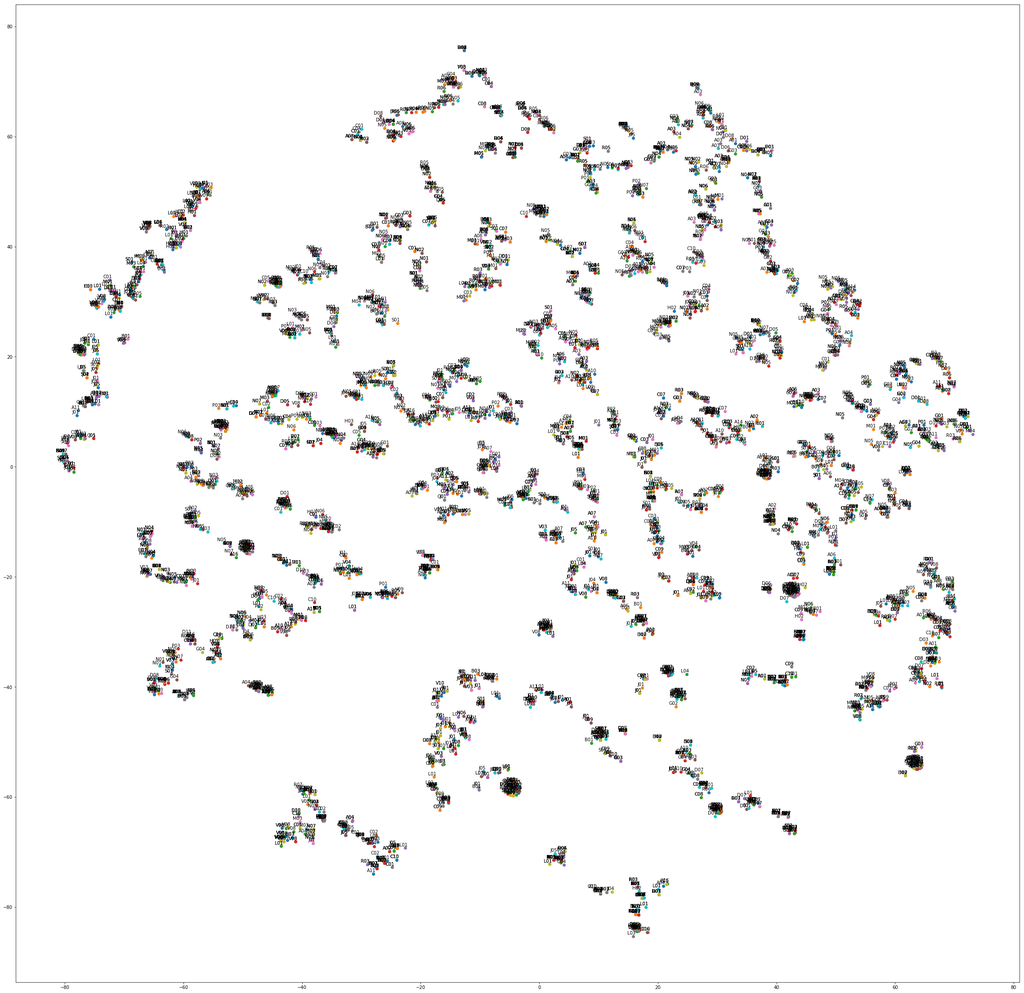

```python
# Importing Modules
from sklearn import datasets
from sklearn.manifold import TSNE
import matplotlib.pyplot as plt
import pandas as pd
from IPython.display import SVG

kegginfo=pd.read_csv('Kegg_ATC_database_info.csv')
keggdata=pd.read_csv('ATC_KEGG_DRUG_DATABASE.csv')
keggcompl=pd.merge(kegginfo,keggdata,on='KEGG_code')
keggclean=keggcompl.drop_duplicates()

# Loading dataset
df = keggclean
df.data = keggclean[['MW','logP','TPSA','HBD','HBA1','HBA2']]
# Defining Model
model = TSNE(learning_rate=100)

# Fitting Model
transformed = model.fit_transform(df.data)

# Plotting 2d t-Sne
x=[]
y=[]
coord=[]
labels=[]
codes=keggclean['ATC_full_code']
labs=codes.str[:3].reset_index(drop=True)
#labs.reset_index(drop=True)
for i in range(0,len(labs)-1,1):
    x.append(transformed[i, 0])
    y.append(transformed[i, 1])
    coord.append((x, y))
    labels.append(labs[i])

plt.figure(figsize=(40, 40))

for i in range(0,len(labs)-1,1): #get (0, label)
   # x, y = coord[i] #2 dim
    plt.scatter(x[i], y[i])
    plt.annotate(labels[i],xy=(x[i], y[i]),xytext=(5, 2),textcoords='offset points',ha='right',va='bottom')

plt.savefig("KEGG_MAP2.png",dpi=500)
plt.savefig('KEGG_MAP2.svg')
plt.show()
```

Finally, we can study the properties of all compounds of ATC database in KEGG_DRUG repository (lets observe some of them are duplicated because have more than single classification so they belong at different ATC subgroups).

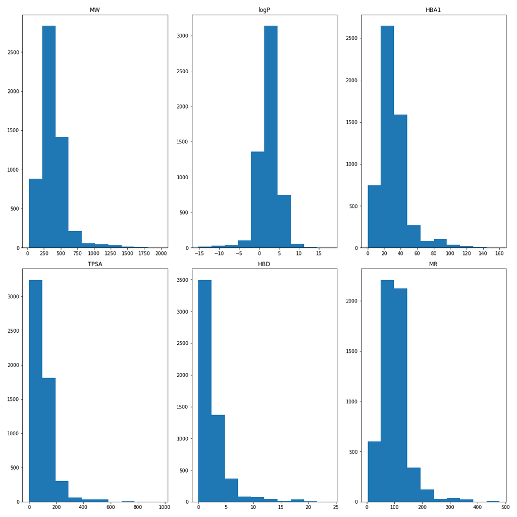

```python
import matplotlib.pyplot as plt

fig, axs = plt.subplots(2, 3, constrained_layout=True,figsize=(15,15))

axs[0, 0].hist(keggclean['MW']);
axs[0, 0].set_title('MW')
axs[0, 1].hist(keggclean['logP']);
axs[0, 1].set_title('logP')
axs[0, 2].hist(keggclean['HBA1']);
axs[0, 2].set_title('HBA1')
axs[1, 1].hist(keggclean['HBD']);
axs[1, 1].set_title('HBD')
axs[1, 0].hist(keggclean['TPSA']);
axs[1, 0].set_title('TPSA')
axs[1, 2].hist(keggclean['MR']);
axs[1, 2].set_title('MR')

for ax in axs.flat:
    ax.set(xlabel='', ylabel='')

plt.tight_layout()
#plt.subplots_adjust(left= 0.1, bottom=0.05 , right=0.9, top=0.95, wspace=0.5, hspace=0.5)

plt.show()
```

```python
import numpy as np
from scipy import io
from scipy.stats import kurtosis,skew,itemfreq,describe,moment,mode,sem,hmean

data=[]
param='logP'
data=keggclean[param]
print("***********************************")
print("Statistical Summary for "+param+" :")
print("***********************************")
print("mean:          ",round(np.mean(data),2))
print("mode counts:   ",mode(data)[1][0])
print("mode:          ",round(mode(data)[0][0],2))
print("SEM:           ",round(sem(data),2))
print("std:           ",round(np.std(data),2))
print('skew:          ',round(skew(data),2))
print("Kurtosis:      ",round(kurtosis(data),2))
print("max:           ",round(np.max(data),2))
print("min:           ",round(np.min(data),2))
print("Percentile 25 :",round(np.percentile(data,25),2))
print("Percentile 75 :",round(np.percentile(data,75),2))
print("Percentile 10 :",round(np.percentile(data,10),2))
print("Percentile 90 :",round(np.percentile(data,90),2))
print("***********************************")
print("***********************************")
```

```
Statistical Summary for logP :
mean:           2.41
mode counts:    40
mode:           7.14
SEM:            0.04
std:            2.67
skew:           -1.12
Kurtosis:       6.14
max:            17.85
min:            -15.23
Percentile 25 : 1.19
Percentile 75 : 3.94
Percentile 10 : -0.46
Percentile 90 : 5.25
```

```python
data=[]
param='MW'
data=keggclean[param]
print("***********************************")
print("Statistical Summary for "+param+" :")
print("***********************************")
print("mean:          ",round(np.mean(data),2))
print("mode counts:   ",mode(data)[1][0])
print("mode:          ",round(mode(data)[0][0],2))
print("SEM:           ",round(sem(data),2))
print("std:           ",round(np.std(data),2))
print('skew:          ',round(skew(data),2))
print("Kurtosis:      ",round(kurtosis(data),2))
print("max:           ",round(np.max(data),2))
print("min:           ",round(np.min(data),2))
print("Percentile 25 :",round(np.percentile(data,25),2))
print("Percentile 75 :",round(np.percentile(data,75),2))
print("Percentile 10 :",round(np.percentile(data,10),2))
print("Percentile 90 :",round(np.percentile(data,90),2))
print("***********************************")
print("***********************************")
```

```
Statistical Summary for MW :
mean:           377.54
mode counts:    45
mode:           434.5
SEM:            2.58
std:            191.01
skew:           2.33
Kurtosis:       9.93
max:            2002.15
min:            28.01
Percentile 25 : 265.37
Percentile 75 : 458.6
Percentile 10 : 184.21
Percentile 90 : 557.61
```

```python
data=[]
param='TPSA'
data=keggclean[param]
print("***********************************")
print("Statistical Summary for "+param+" :")
print("***********************************")
print("mean:          ",round(np.mean(data),2))
print("mode counts:   ",mode(data)[1][0])
print("mode:          ",round(mode(data)[0][0],2))
print("SEM:           ",round(sem(data),2))
print("std:           ",round(np.std(data),2))
print('skew:          ',round(skew(data),2))
print("Kurtosis:      ",round(kurtosis(data),2))
print("max:           ",round(np.max(data),2))
print("min:           ",round(np.min(data),2))
print("Percentile 25 :",round(np.percentile(data,25),2))
print("Percentile 75 :",round(np.percentile(data,75),2))
print("Percentile 10 :",round(np.percentile(data,10),2))
print("Percentile 90 :",round(np.percentile(data,90),2))
print("***********************************")
print("***********************************")
```

```
Statistical Summary for TPSA :
mean:           98.1
mode counts:    206
mode:           100.9
SEM:            1.05
std:            77.73
skew:           2.95
Kurtosis:       15.21
max:            972.16
min:            0.0
Percentile 25 : 49.33
Percentile 75 : 121.32
Percentile 10 : 31.49
Percentile 90 : 182.22
```

```python
data=[]
param='HBA1'
data=keggclean[param]
print("***********************************")
print("Statistical Summary for "+param+" :")
print("***********************************")
print("mean:          ",round(np.mean(data),2))
print("mode counts:   ",mode(data)[1][0])
print("mode:          ",round(mode(data)[0][0],2))
print("SEM:           ",round(sem(data),2))
print("std:           ",round(np.std(data),2))
print('skew:          ',round(skew(data),2))
print("Kurtosis:      ",round(kurtosis(data),2))
print("max:           ",round(np.max(data),2))
print("min:           ",round(np.min(data),2))
print("Percentile 25 :",round(np.percentile(data,25),2))
print("Percentile 75 :",round(np.percentile(data,75),2))
print("Percentile 10 :",round(np.percentile(data,10),2))
print("Percentile 90 :",round(np.percentile(data,90),2))
print("***********************************")
print("***********************************")
```

```
Statistical Summary for HBA1 :
mean:           30.42
mode counts:    215
mode:           26
SEM:            0.24
std:            17.5
skew:           2.17
Kurtosis:       7.72
max:            160
min:            0
Percentile 25 : 19.0
Percentile 75 : 37.0
Percentile 10 : 14.0
Percentile 90 : 47.0
```

```python
data=[]
param='HBD'
data=keggclean[param]
print("***********************************")
print("Statistical Summary for "+param+" :")
print("***********************************")
print("mean:          ",round(np.mean(data),2))
print("mode counts:   ",mode(data)[1][0])
print("mode:          ",round(mode(data)[0][0],2))
print("SEM:           ",round(sem(data),2))
print("std:           ",round(np.std(data),2))
print('skew:          ',round(skew(data),2))
print("Kurtosis:      ",round(kurtosis(data),2))
print("max:           ",round(np.max(data),2))
print("min:           ",round(np.min(data),2))
print("Percentile 25 :",round(np.percentile(data,25),2))
print("Percentile 75 :",round(np.percentile(data,75),2))
print("Percentile 10 :",round(np.percentile(data,10),2))
print("Percentile 90 :",round(np.percentile(data,90),2))
print("***********************************")
print("***********************************")
```

```
Statistical Summary for HBD :
mean:           2.65
mode counts:    1657
mode:           2
SEM:            0.04
std:            2.64
skew:           3.15
Kurtosis:       13.7
max:            24
min:            0
Percentile 25 : 1.0
Percentile 75 : 3.0
Percentile 10 : 1.0
Percentile 90 : 5.0
```

Let's verify if Lipinski Rule of five () is satisfied by the average:

1. No more than 5 hydrogen bond donors (the total number of nitrogen–hydrogen and oxygen–hydrogen bonds)
2. No more than 10 hydrogen bond acceptors (all nitrogen or oxygen atoms)
3. A molecular mass less than 500 daltons
4. An octanol-water partition coefficient (log P) that does not exceed 5

https://en.wikipedia.org/wiki/Lipinski%27s_rule_of_five

```python
import numpy as np
round(np.mean(keggclean),2)
```

```
MW      377.54
logP      2.41
MR      101.98
TPSA     98.10
HBA1     30.42
HBD       2.65
HBA2      5.52
dtype: float64
```

As we can see, condition 1 is satisfied (HBD=2.64 < 5), condition 2 is also satisfied looking at 2 (HBA2 < 10), condition 3 is also satisfied (MW = 377.54 < 500) and also condition 4 (logP = 2.41 < 5)

To finish, lets compute and analyze a more sophisticated set of molecular descriptors based on PED (pairwise Energy descriptors: https://www.nature.com/articles/srep43738 ). This descriptors are a compat set that account for rellevant electrostatic patterns in small compounds based on atom partial charges (qi) and spatial coordinates of the atom points (xi,yi,zi) and interactions between them by Electrostatic energy:

$E_{i,j}=\frac{q_i*q_j}{r_{i,j}}$

Where $r_{i,j}$ is the Euclidian distance between atom points i and j and qi,qj their respective partial charges. A good method to obtain partial charges is by computing them using MMFF94 method and Openbabel software.

Then, using the structure provided by original MOL2 files of LIGANDBOX, the MMFF94 partialcharges are computed:

```python
!obabel -imol2 KEGG_DRUG.mol2 -omol2 -O KEGG_DRUG_MMFF.mol2 --partialcharge MMFF94
```

```
7283 molecules converted
```

Now lets compute descriptors using the methodology described at https://www.nature.com/articles/srep43738 ) and read the file.

```python
keggped=pd.read_csv('KEGG_PED_ATC.csv')
keggped.head()
```

|  | u1 | u2 | u3 | u4 | u5 | u6 | u7 | u8 | u9 | u10 | u11 | u12 | Label |
| --- | --- | --- | --- | --- | --- | --- | --- | --- | --- | --- | --- | --- | --- |
| 0 | -10.7069 | -10.3727 | -10.0872 | -4.5394 | -2.4732 | -2.1237 | 1.5662 | 3.1255 | 3.4035 | 3.6360 | 5.1953 | 5.2640 | D05864_A01AA02 |
| 1 | -10.6997 | -10.3749 | -10.0872 | -4.5394 | -2.4691 | -2.1265 | 1.5664 | 3.1267 | 3.4031 | 3.6332 | 5.1948 | 5.2713 | D05864_A12CD02 |
| 2 | -6.0389 | -6.0339 | -4.6060 | -4.5929 | -4.5486 | -4.5153 | 1.5802 | 1.5825 | 2.4947 | 2.6046 | 3.0921 | 3.1153 | D05241_A01AA03 |
| 3 | -1.2514 | -1.2513 | 0.8987 | 1.5853 | -4.5486 | -4.5153 | 0.0000 | 0.0000 | -1.2514 | -1.2513 | 0.8987 | 1.5853 | D00008_A01AB02 |
| 4 | -1.2514 | -1.2514 | 0.8986 | 1.5854 | -4.5486 | -4.5153 | 0.0000 | 0.0000 | -1.2514 | -1.2514 | 0.8986 | 1.5854 | D00008_D08AX01 |

Try now to make a MAP to see the clusters.

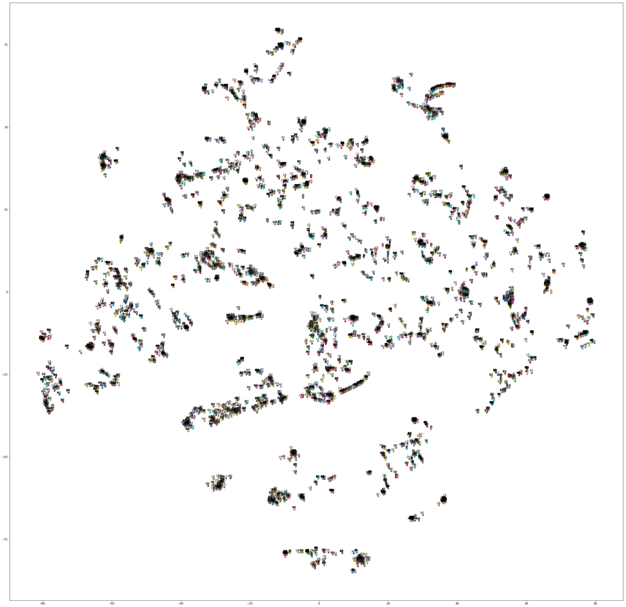

```python
# Importing Modules
from sklearn import datasets
from sklearn.manifold import TSNE
import matplotlib.pyplot as plt
import pandas as pd
from IPython.display import SVG

# Loading dataset
df = keggped
df.data = keggped[['u1','u2','u3','u4','u9','u10','u11','u12']]
# Defining Model
model = TSNE(learning_rate=100)

# Fitting Model
transformed = model.fit_transform(df.data)

# Plotting 2d t-Sne
x=[]
y=[]
coord=[]
labels=[]
codes=keggped['Label']
labs=codes.str[7:9].reset_index(drop=True)
#labs.reset_index(drop=True)
for i in range(0,len(labs)-1,1):
    x.append(transformed[i, 0])
    y.append(transformed[i, 1])
    coord.append((x, y))
    labels.append(labs[i])

plt.figure(figsize=(40, 40))

for i in range(0,len(labs)-1,1): #get (0, label)
   # x, y = coord[i] #2 dim
    plt.scatter(x[i], y[i])
    plt.annotate(labels[i],xy=(x[i], y[i]),xytext=(5, 2),textcoords='offset points',ha='right',va='bottom')

plt.savefig("KEGG_MAP_PED_color.png",dpi=500)
plt.savefig('KEGG_MAP_PED_color.svg')



'''
# Plotting 2d t-Sne
x=[]
y=[]
coord=[]
labels=[]

#labs.reset_index(drop=True)
for i in range(0,len(labs)-1,1):
    x.append(transformed[i, 0])
    y.append(transformed[i, 1])

plt.figure(figsize=(40, 40))
plt.scatter(x, y)

plt.savefig("KEGG_PED8_MAP.png",dpi=500)
plt.savefig('KEGG_PED8_MAP.svg')
plt.show()'''

plt.show()
```

```python
from scipy import io
from scipy.stats import kurtosis,skew,itemfreq,describe,moment,mode,sem,hmean
print("Average of descriptors :",round(np.mean(keggped),2))#,"+/-",round(np.std(keggped),2))
```

```
Average of descriptors : u1    -5.76
u2    -5.24
u3    -4.67
u4    -4.09
u5    -3.36
u6    -3.02
u7     1.71
u8     1.81
u9     1.93
u10    2.11
u11    2.41
u12    2.93
dtype: float64
```

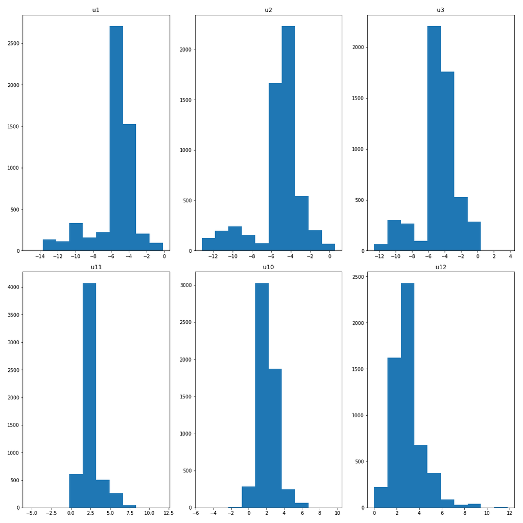

```python
import matplotlib.pyplot as plt

fig, axs = plt.subplots(2, 3, constrained_layout=True,figsize=(15,15))

axs[0, 0].hist(keggped['u1']);
axs[0, 0].set_title('u1')
axs[0, 1].hist(keggped['u2']);
axs[0, 1].set_title('u2')
axs[0, 2].hist(keggped['u3']);
axs[0, 2].set_title('u3')
axs[1, 1].hist(keggped['u10']);
axs[1, 1].set_title('u10')
axs[1, 0].hist(keggped['u11']);
axs[1, 0].set_title('u11')
axs[1, 2].hist(keggped['u12']);
axs[1, 2].set_title('u12')

for ax in axs.flat:
    ax.set(xlabel='', ylabel='')

plt.tight_layout()
#plt.subplots_adjust(left= 0.1, bottom=0.05 , right=0.9, top=0.95, wspace=0.5, hspace=0.5)

plt.show()
```

Now, lets take some drug candidates to be effective against COVID19 and try to search the most similar drugs to them in KEGG database. For instance, which compounds in KEGG_DATABASE are more similar to this set of compounds:

### Drugs that are currently testing against COVID19

- From source:https://www.linkedin.com/pulse/covid-19-treatments-clinical-trials-ana-gavald%25C3%25A1/?trackingId=tzMbX9MOQUK8qJMQDKuE3w%3D%3D
- REMDESIVIR - Antiviral, prefered treatment against COVID-19 (https://en.wikipedia.org/wiki/Remdesivir ), (https://www.foxnews.com/science/remdesivir-what-to-know-about-potential-coronavirus-treatment ) ,( https://www.nature.com/articles/d41573-020-00016-0 )
- CHLOROQUINE - Antimalarial (https://en.wikipedia.org/wiki/Chloroquine )
- HYDROXYCHLOROQUINE - Derivative that improves CHLOROQUINE effectiveness (https://www.nature.com/articles/s41421-020-0156-0.pdf )
- LOPINAVIR - Antiviral against VIH (https://en.wikipedia.org/wiki/Lopinavir )
- DARUNAVIR - Antiviral against VIH (https://en.wikipedia.org/wiki/Darunavir )
- FAVIPIRAVIR - Effective with Ebola and other viruses (https://www.livescience.com/flu-drug-could-treat-coronavirus.html ) (https://www.redaccionmedica.com/secciones/sanidad-hoy/coronavirus-tratamiento-china-anuncia-resultados-del-antiviral-favipiravir-4773 )
- THALIDOMIDE - (https://en.wikipedia.org/wiki/Thalidomide )
- FINGOLIMOD - Inmunomodulator effect. Multiple sclerosis (MS) threatment (https://en.wikipedia.org/wiki/Fingolimod )
- GALIDESIVIR - (https://en.wikipedia.org/wiki/Galidesivir )

Some of this set are not yet in this version of KEGG database. Lets search for compounds similar to HYDROXYCHLOROQUINE...Is this compound in the dataset?

```python
import pandas as pd
kegginfo=pd.read_csv('Kegg_ATC_database_info.csv')
keggdata=pd.read_csv('ATC_KEGG_DRUG_DATABASE.csv')
keggcompl=pd.merge(kegginfo,keggdata,on='KEGG_code')
keggclean=keggcompl.drop_duplicates()
keggmol=keggclean[keggclean['CompoundName'].str[:19]==' Hydroxychloroquine']
keggmol
```

|  | KEGG_code | CompoundName | ATC_label_class | ATC_full_code | BigGroup_ATC_class | SMILES | MW | logP | MR | TPSA | HBA1 | HBD | HBA2 | InChIKey | formula | cansmiNS | InChI |
| --- | --- | --- | --- | --- | --- | --- | --- | --- | --- | --- | --- | --- | --- | --- | --- | --- | --- |
| 13309 | D08050 | Hydroxychloroquine (INN) | Aminoquinolines | P01BA02 | ANTIPARASITIC PRODUCTS, INSECTICIDES AND REPEL... | c1c(cc2c(c1)c(ccn2)N[C@@H](CCC[N@@H+](CCO)CC)C)Cl | 336.879 | 2.4389 | 99.8302 | 49.59 | 30 | 3 | 3 | XXSMGPRMXLTPCZ-CQSZACIVSA-O | C18H27ClN3O+ | OCC[NH+](CCCC(Nc1ccnc2c1ccc(c2)Cl)C)CC | InChI=1S/C18H26ClN3O/c1-3-22(11-12-23)10-4-5-1... |
| 13310 | D02114 | Hydroxychloroquine sulfate (JAN/USP) | Aminoquinolines | P01BA02 | ANTIPARASITIC PRODUCTS, INSECTICIDES AND REPEL... | N([C@@H](CCC[N@@H+](CCO)CC)C)c1c2c(ncc1)cc(cc2)Cl | 336.879 | 2.4389 | 99.8302 | 49.59 | 30 | 3 | 3 | XXSMGPRMXLTPCZ-CQSZACIVSA-O | C18H27ClN3O+ | OCC[NH+](CCCC(Nc1ccnc2c1ccc(c2)Cl)C)CC | InChI=1S/C18H26ClN3O/c1-3-22(11-12-23)10-4-5-1... |

Then search in PED KEGG database the KEGG codes: D08050

```python
keggmol=keggped[keggped['Label'].str[:6]=='D08050']
keggmol
```

|  | u1 | u2 | u3 | u4 | u5 | u6 | u7 | u8 | u9 | u10 | u11 | u12 | Label |
| --- | --- | --- | --- | --- | --- | --- | --- | --- | --- | --- | --- | --- | --- |
| 4791 | -6.0088 | -4.8752 | -4.5808 | -4.5072 | -4.5044 | -3.105 | 1.5525 | 1.5787 | 1.5927 | 1.8253 | 2.2094 | 3.137 | D08050_P01BA02 |

Now lets search for similar compounds using Manhattan distance metrics:

```python
S=[]
desf = open('Similarities_'+str(keggmol.iloc[0:1,12:13].values[0][0])+'.shd', 'w')
desf.write('label,S\n')

for j in range(0,np.shape(keggped)[0]-1,1):
#    print(str(j))
    MhD=0.0
    for i in range(0,np.shape(keggped)[1]-2,1):
        MhD=MhD+1/12*np.absolute(keggped.iloc[j:j+1,i:i+1].values[0][0]-keggmol.iloc[0:1,i:i+1].values[0][0])
    S=1.0/(1.0+MhD)
    desf.write(str(keggped.iloc[j:j+1,12:13].values[0][0])+','+str(round(S,4))+'\n')
```

```python
desf.close()
df=pd.read_csv('Similarities_'+str(keggmol.iloc[0:1,12:13].values[0][0])+'.shd') #_'+str(keggmol.iloc[0:1,12:13])+'.shd')

dfs=df.sort_values(by='S', ascending=False).reset_index(drop=True)
dfs.head(n=20)
```

|  | label | S |
| --- | --- | --- |
| 0 | D08050_P01BA02 | 1.0000 |
| 1 | D02114_P01BA02 | 0.9612 |
| 2 | D02548_P01AX05 | 0.9468 |
| 3 | D02243_N06BX01 | 0.9349 |
| 4 | D00993_N06BX01 | 0.9318 |
| 5 | D08179_P01AX05 | 0.9314 |
| 6 | D05024_C08CX01 | 0.9302 |
| 7 | D07759_S01FA04 | 0.9285 |
| 8 | D02125_P01BA01 | 0.9280 |
| 9 | D07680_P01BA01 | 0.9273 |
| 10 | D10014_V09AB03 | 0.9273 |
| 11 | D01290_C04AE02 | 0.9269 |
| 12 | D02366_P01BA01 | 0.9266 |
| 13 | D03469_P01BA01 | 0.9249 |
| 14 | D08035_N05AD01 | 0.9206 |
| 15 | D08244_C04AX21 | 0.9190 |
| 16 | D03450_C04AX26 | 0.9162 |
| 17 | D00718_G04BD02 | 0.9144 |
| 18 | D08216_N06AX03 | 0.9129 |
| 19 | D01358_N06AX03 | 0.9120 |

```python
simfound=[]
for j in range(0,25,1):
#    str(df.iloc[j:j+1].values[0][0])[:6]
    simfound.append(keggcompl[keggcompl['KEGG_code']==str(dfs.iloc[j:j+1].values[0][0])[:6]])

#sb=simfound.reset_index(drop=True)
```

```python
swr = open('Candidates.smi', 'w')
for j in range(0,25,1):
    if(len(simfound[j])>0):
#        print(simfound[j].values[0][5]+' '+simfound[j].values[0][0]+'\n')
        swr.write(simfound[j].values[0][5]+' '+simfound[j].values[0][0]+'\n')
swr.close()
```

```python
!obabel -ismi Candidates.smi -osvg -O Candidates.svg
```

```
25 molecules converted
```

```python
from IPython.display import SVG
display(SVG('Candidates.svg'))
```

[figure not shown]

```python
keggmol=keggclean[keggclean['KEGG_code'].str[:10]=='D02114']
keggmol
```

|  | KEGG_code | CompoundName | ATC_label_class | ATC_full_code | BigGroup_ATC_class | SMILES | MW | logP | MR | TPSA | HBA1 | HBD | HBA2 | InChIKey | formula | cansmiNS | InChI |
| --- | --- | --- | --- | --- | --- | --- | --- | --- | --- | --- | --- | --- | --- | --- | --- | --- | --- |
| 13310 | D02114 | Hydroxychloroquine sulfate (JAN/USP) | Aminoquinolines | P01BA02 | ANTIPARASITIC PRODUCTS, INSECTICIDES AND REPEL... | N([C@@H](CCC[N@@H+](CCO)CC)C)c1c2c(ncc1)cc(cc2)Cl | 336.879 | 2.4389 | 99.8302 | 49.59 | 30 | 3 | 3 | XXSMGPRMXLTPCZ-CQSZACIVSA-O | C18H27ClN3O+ | OCC[NH+](CCCC(Nc1ccnc2c1ccc(c2)Cl)C)CC | InChI=1S/C18H26ClN3O/c1-3-22(11-12-23)10-4-5-1... |

```python
keggmol=keggclean[keggclean['KEGG_code'].str[:10]=='D02243']
keggmol
```

|  | KEGG_code | CompoundName | ATC_label_class | ATC_full_code | BigGroup_ATC_class | SMILES | MW | logP | MR | TPSA | HBA1 | HBD | HBA2 | InChIKey | formula | cansmiNS | InChI |
| --- | --- | --- | --- | --- | --- | --- | --- | --- | --- | --- | --- | --- | --- | --- | --- | --- | --- |
| 13166 | D02243 | Meclofenoxate hydrochloride (JP17) | Other psychostimulants and nootropics | N06BX01 | NERVOUS SYSTEM | c1(ccc(cc1)Cl)OCC(=O)OCC[NH+](C)C | 258.721 | 0.4065 | 67.4177 | 39.97 | 20 | 1 | 3 | XZTYGFHCIAKPGJ-UHFFFAOYSA-O | C12H17ClNO3+ | O=C(COc1ccc(cc1)Cl)OCC[NH+](C)C | InChI=1S/C12H16ClNO3/c1-14(2)7-8-16-12(15)9-17... |

```python
keggmol=keggclean[keggclean['CompoundName'].str[:10]==' Lopinavir']
keggmol
```

|  | KEGG_code | CompoundName | ATC_label_class | ATC_full_code | BigGroup_ATC_class | SMILES | MW | logP | MR | TPSA | HBA1 | HBD | HBA2 | InChIKey | formula | cansmiNS | InChI |
| --- | --- | --- | --- | --- | --- | --- | --- | --- | --- | --- | --- | --- | --- | --- | --- | --- | --- |
| 11854 | D02498 | Lopinavir mixture with ritonavir | Antivirals for treatment of HIV infections, c... | J05AR10 | ANTIINFECTIVES FOR SYSTEMIC USE | [C@H](Cc1ccccc1)(C[C@@H]([C@H](Cc1ccccc1)NC(=O... | 720.944 | 7.0779 | 197.824 | 202.26 | 59 | 4 | 13 | NCDNCNXCDXHOMX-XGKFQTDJSA-N | C37H48N6O5S2 | O=C(NC(C(CC(Cc1ccccc1)NC(=O)C(C(C)C)NC(=O)N(Cc... | InChI=1S/C37H48N6O5S2/c1-24(2)33(42-36(46)43(5... |

```python
keggmol=keggped[keggped['Label'].str[:6]=='D02498']
keggmol
```

|  | u1 | u2 | u3 | u4 | u5 | u6 | u7 | u8 | u9 | u10 | u11 | u12 | Label |
| --- | --- | --- | --- | --- | --- | --- | --- | --- | --- | --- | --- | --- | --- |
| 3538 | -5.9405 | -5.4299 | -5.2435 | -4.6301 | -4.487 | -4.3369 | 2.3009 | 2.5171 | 2.6264 | 2.6413 | 2.691 | 2.9911 | D02498_J05AR10 |

```python
S=[]
desf = open('Similarities_'+str(keggmol.iloc[0:1,12:13].values[0][0])+'.shd', 'w')
desf.write('label,S\n')

for j in range(0,np.shape(keggped)[0]-1,1):
#    print(str(j))
    MhD=0.0
    for i in range(0,np.shape(keggped)[1]-2,1):
        MhD=MhD+1/12*np.absolute(keggped.iloc[j:j+1,i:i+1].values[0][0]-keggmol.iloc[0:1,i:i+1].values[0][0])
    S=1.0/(1.0+MhD)
    desf.write(str(keggped.iloc[j:j+1,12:13].values[0][0])+','+str(round(S,4))+'\n')

desf.close()
df=pd.read_csv('Similarities_'+str(keggmol.iloc[0:1,12:13].values[0][0])+'.shd') #_'+str(keggmol.iloc[0:1,12:13])+'.shd')

dfs=df.sort_values(by='S', ascending=False).reset_index(drop=True)
dfs.head(n=20)
```

|  | label | S |
| --- | --- | --- |
| 0 | D02498_J05AR10 | 1.0000 |
| 1 | D00427_J05AE03 | 0.9590 |
| 2 | D02504_J01CA19 | 0.9102 |
| 3 | D00202_A07AA02 | 0.8967 |
| 4 | D07326_N05CD11 | 0.8963 |
| 5 | D00203_A07AA07 | 0.8941 |
| 6 | D08145_N05CD11 | 0.8940 |
| 7 | D01223_L01BC06 | 0.8922 |
| 8 | D00203_G01AA03 | 0.8909 |
| 9 | D00203_A01AB04 | 0.8906 |
| 10 | D00203_J02AA01 | 0.8904 |
| 11 | D07130_A16AA05 | 0.8900 |
| 12 | D01631_V04CG04 | 0.8879 |
| 13 | D08025_V03AB32 | 0.8874 |
| 14 | D00202_G01AA01 | 0.8863 |
| 15 | D01990_D10AF01 | 0.8863 |
| 16 | D03903_A01AB22 | 0.8861 |
| 17 | D07524_A16AA06 | 0.8857 |
| 18 | D00202_D01AA01 | 0.8850 |
| 19 | D00424_J04AB04 | 0.8830 |

```python
simfound=[]
for j in range(0,25,1):
#    str(df.iloc[j:j+1].values[0][0])[:6]
    simfound.append(keggcompl[keggcompl['KEGG_code']==str(dfs.iloc[j:j+1].values[0][0])[:6]])

swr = open('Candidates.smi', 'w')
for j in range(0,25,1):
    if(len(simfound[j])>0):
#        print(simfound[j].values[0][5]+' '+simfound[j].values[0][0]+'\n')
        swr.write(simfound[j].values[0][5]+' '+simfound[j].values[0][0]+'\n')
swr.close()
!obabel -ismi Candidates.smi -osvg -O Candidates.svg
display(SVG('Candidates.svg'))
```

```
25 molecules converted
```

[figure not shown]

The most similar one is D00427. Lets search for that compound in the database:

```python
keggmol=keggclean[keggclean['KEGG_code'].str[:10]=='D00427']
keggmol
```

|  | KEGG_code | CompoundName | ATC_label_class | ATC_full_code | BigGroup_ATC_class | SMILES | MW | logP | MR | TPSA | HBA1 | HBD | HBA2 | InChIKey | formula | cansmiNS | InChI |
| --- | --- | --- | --- | --- | --- | --- | --- | --- | --- | --- | --- | --- | --- | --- | --- | --- | --- |
| 11810 | D00427 | Ritonavir (JAN/USAN/INN) | Protease inhibitors | J05AE03 | ANTIINFECTIVES FOR SYSTEMIC USE | [C@H](Cc1ccccc1)(C[C@@H]([C@H](Cc1ccccc1)NC(=O... | 720.944 | 7.0779 | 197.824 | 202.26 | 59 | 4 | 13 | NCDNCNXCDXHOMX-XGKFQTDJSA-N | C37H48N6O5S2 | O=C(NC(C(CC(Cc1ccccc1)NC(=O)C(C(C)C)NC(=O)N(Cc... | InChI=1S/C37H48N6O5S2/c1-24(2)33(42-36(46)43(5... |

Ritonavir, a possible compound with similar effects than Lopinavir: https://www.nature.com/articles/s41591-020-0849-9